# 1 Lecture 1

## 1.1 References

- https://www.daniellitt.com/tale-cohomology
- (**milneLEC?**), (**milne_2017?**), (**freitag_kiehl_2013?**), (**katz?**)

## 1.2 Intro

Prerequisites:

- Homological Algebra
  - Abelian Categories
  - Derived Functors
  - Spectral Sequences (just exposure!)
- Sheaf theory and sheaf cohomology
- Schemes (Hartshorne II and III)

Outline/Goals:

- Basics of etale cohomology
  - Etale morphism
  - Grothendieck topologies
  - The etale topology
  - Etale cohomology and the basis theorems
  - Etale cohomology of curves
  - Comparison theorems to singular cohomology
  - Focused on the case where coefficients are a constructible sheaf.
- Prove the Weil Conjectures (more than one proof)
  - Proving the Riemann Hypothesis for varieties over finite fields

  > One of the greatest pieces of 20th century mathematics!
- Topics
  - Weil 2 (Strengthening of RH, used in practice)
  - Formality of algebraic varieties (topological features unique to varieties)
  - Other things (monodromy, refer to Katz’ AWS notes)

## 1.3 What is Etale Cohomology?

Suppose $X/{\mathbb{C}}$ is a quasiprojective variety: a finite type separated integral ${\mathbb{C}}{\hbox{-}}$scheme. If you take the complex points, it naturally has the structure of a complex analytic space $X({\mathbb{C}})^{\text{an}}$: you can give it the Euclidean topology, which is much finer than the Zariski topology. For a nice topological space, we can associate the singular cohomology $H^i(X({\mathbb{C}})^{\text{an}}, {\mathbb{Z}})$, which satisfies several nice properties:

- Finitely generated ${\mathbb{Z}}{\hbox{-}}$modules
- Extra Hodge structure when tensored up to ${\mathbb{C}}$ (same as ${\mathbb{C}}$ coefficients)
- Cycle classes (i.e. associate to a subvariety a class in cohomology)

Goal of etale cohomology: do something similar for much more general “nice” schemes. Note that some of these properties are special to complex varieties. (E.g. finitely generated: not true for a random topological space.)

We’ll associate $X$ a “nice scheme” $\rightsquigarrow H^i(X_{\text{et}}, {\mathbb{Z}}/\ell^n{\mathbb{Z}})$. Take the inverse limit over all $n$ to obtain the $\ell{\hbox{-}}$adic cohomology $H^i(X_{\text{et}}, {\mathbb{Z}}_\ell)$. You can tensor with ${\mathbb{Q}}$ to get something with ${\mathbb{Q}}_\ell$ coefficients. And as in singular cohomology, you can a “twisted coefficient system.”

What are some nice schemes?

- $X = \operatorname{Spec}{\mathcal{O}}_k$, the ring of integers over a number field.
- $X$ a variety over an algebraically closed field
  - Typical, most analogous to taking a variety over ${\mathbb{C}}$.
- $X$ a variety over a non-algebraically closed field

Some comparisons between the last two cases:

- For ${\mathbb{C}}{\hbox{-}}$ variety, $H^i_{\text{sing}}$ will vanish above $i=2d$.
- Over a finite field, $H^i$ will vanish for $i>2d+1$ but generally not vanish for $i=2d+1$.

In good situations, these are finitely generated ${\mathbb{Z}}/\ell^n{\mathbb{Z}}{\hbox{-}}$modules, have Mayer-Vietoris and excision sequences, spectral sequences, etc. Related invariants: for a scheme with a geometric[^1] point: $(X, \mkern 1.5mu\overline{\mkern-1.5mux\mkern-1.5mu}\mkern 1.5mu) \rightsquigarrow \pi_1^{\text{étale}}(X, \mkern 1.5mu\overline{\mkern-1.5mux\mkern-1.5mu}\mkern 1.5mu)$, which is a profinite topological group.

More invariants beyond the scope of this course:

- Higher homotopy groups
- Homotopy type (equivalence class of spaces)

So we want homotopy-theoretic invariants for varieties.

This cohomology theory is necessarily weird! The following theorem explains why. The slogan: there is no cohomology theory with ${\mathbb{Q}}$ coefficients.

There does not exists a cohomology theory for schemes over $\mkern 1.5mu\overline{\mkern-1.5mu{\mathbb{F}}\mkern-1.5mu}\mkern 1.5mu_q$ with the following properties:

1. Functorial
2. Satisfies the Kunneth formula
3. For $E$ an elliptic curve, $H^1(E) = {\mathbb{Q}}^2$.

Take $E$ to be a supersingular elliptic curve. Then $\operatorname{End}(E) \otimes{\mathbb{Q}}$ is a quaternion algebra, and use the fact that there are no algebra morphisms $R\to \operatorname{Mat}_{2\times 2}({\mathbb{Q}})$.

Functoriality and Kunneth implies that $\operatorname{End}(E)\curvearrowright E$ yields an action on $H^1(E)$, which is precisely an algebra morphism $\operatorname{End}(E) \to \operatorname{Mat}_{2\times 2}({\mathbb{Q}})$, a contradiction.

The content here: the sum of two endomorphisms act via their sum on $H^1$.

Prove the same thing for ${\mathbb{Q}}_p$ coefficients, where $p$ divides the characteristic of the ground field. Proof the same, just need to know what quaternion algebras show up.

This forces using some funky type of coefficients.

## 1.4 What are the Weil Conjectures?

Suppose $X/{\mathbb{F}}_q$ is a variety, then
$$\begin{align*}
\zeta_X(t) = \exp{\sum_{n>0} { {{\left\lvert {X({\mathbb{F}}_{q^n})} \right\rvert} \over n} t^n } }
.\end{align*}$$

- ${\frac{\partial }{\partial t}\,} \log \zeta_X(t)$ is an ordinary generating function for the number of rational points.
- Slogan: locations of zeros and poles of a meromorphic function control the growth rate of the coefficients of the Taylor series of the logarithmic derivative.

Make this slogan precise for rational functions, i.e. ratios of two polynomials.

1. $\zeta_x(t)$ is a rational function.
2. (Functional equation) For $X$ smooth and proper
   $$\begin{align*}
   \zeta_X(q^{-n} t^{-1}) = \pm q^{nE \over 2} t^E \zeta_X(t)
   .\end{align*}$$
3. (RH) All roots and poles of $\zeta_X(t)$ have absolute value $q^{i\over 2}$ with $i\in {\mathbb{Z}}$, and these are equal to the $i$th Betti numbers if $X$ lifts to characteristic zero.[^2]

These are all theorems! The proofs:

1. Dwork, using $p{\hbox{-}}$adic methods. Proof here will follow from the fact that $H^i_{\text{étale} }$ are finite-dimensional. Related to the **Lefschetz Trace Formula**, and is how Grothendieck thought about it.
2. Grothendieck, follows from some version of Poincaré duality.
3. (and 4) Deligne.

### 1.4.1 Euler Product

Check the first equality. If you have a point of $\deg(x) = n$, how many ${\mathbb{F}}_{q^n}$ points does this contribute? I.e., how many maps are there $\operatorname{Spec}({\mathbb{F}}_{q^n}) \to \operatorname{Spec}({\mathbb{F}}_{q^n})$ over ${\mathbb{F}}_q$?

There are exactly $n$: it’s $\operatorname{Gal}({\mathbb{F}}_{q^n} / {\mathbb{F}}_q)$. But then division by $n$ drops this contribution to one.

We can keep going by expanding and multiplying out the product:
$$\begin{align*}
\prod_{x\in {\left\lvert {X} \right\rvert}} {1 \over 1 - t^{\deg(x)}}
&= \prod_{x\in {\left\lvert {X} \right\rvert}} (1 + t^{\deg(x)} + t^{2 \deg(x)}) \\
&= \sum_{n\geq 0} \qty{\text{\# of Galois-stable subset of $X(\mkern 1.5mu\overline{\mkern-1.5mu{\mathbb{F}}\mkern-1.5mu}\mkern 1.5mu_{q^n})$ of size $n$}}t^n
.\end{align*}$$

Why? If you have a degree $x$ point, it contributes a stable subset of size $x$: namely the ${\mathbb{F}}_{q^n}$ points of ${\mathbb{F}}_{q^n}$. Taking Galois orbits like that correspond to multiplying this product. But these are the points of some algebraic variety:
$$\begin{align*}
\cdots
= \sum_{n\geq 0} {\left\lvert {\operatorname{Sym}^n(X)({\mathbb{F}}_q)} \right\rvert} t^n
,\end{align*}
where \(\operatorname{Sym}^n(X) \mathrel{\vcenter{:}}= X^n/\Sigma_n\), the action of the symmetric group. Why is that? A \(\mkern 1.5mu\overline{\mkern-1.5mu{\mathbb{F}}\mkern-1.5mu}\mkern 1.5mu_q\) point of \(\operatorname{Sym}^n(X)\) is an unordered \(n{\hbox{-}}\)tuple of \(\mkern 1.5mu\overline{\mkern-1.5mu{\mathbb{F}}\mkern-1.5mu}\mkern 1.5mu_q\) points without an ordering, and asking them to be Galois stable is the same as saying that they are an \({\mathbb{F}}_q\) point.$$

For $X$ a smooth proper curve over ${\mathbb{F}}_q$, $\zeta_X(t)$ is rational.

There is a set map
$$\begin{align*}
\operatorname{Sym}^n X &\to {\operatorname{Pic}}^n X \\
D &\mapsto {\mathcal{O}}(D)
,\end{align*}
where here the divisor is an \(n{\hbox{-}}\)tuple of points.$$

What are the fibers over a line bundle ${\mathcal{O}}(D)$? A linear system, i.e. the projectivization of global sections ${\mathbb{P}}\Gamma(X, {\mathcal{O}}(D))$. What is the expected dimension? To compute the dimension of the space of line bundles on a curve, use Riemann-Roch:
$$\begin{align*}
\dim {\mathbb{P}}\Gamma(X, {\mathcal{O}}(D)) = \deg(D) + 1 - g + \dim H^1(X, {\mathcal{O}}(D)) - 1
.\end{align*}
where the last \(-1\) comes from the fact that this is a projective space.$$

This is because it’s dual to $H^0(X, {\mathcal{O}}(K-D))^\vee$, but this has negative degree and a line bundle of negative degree can never have sections.[^3] Thus the fibers are isomorphic to ${\mathbb{P}}^{n-g}$ for $n>2g-2$. Now make a reduction[^4] and without loss of generality, assume $X({\mathbb{F}}_q) \neq \emptyset$. In this case, ${\operatorname{Pic}}^n(X) \cong {\operatorname{Pic}}^{n+1}(X)$ for all $n$, since you can take ${\mathcal{O}}(P)$ for $P$ a point, a degree 1 line bundle, and tensor with it. It’s an isomorphism because you can tensor with the dual bundle to go back. Thus for all $n>2g-2$,
$$\begin{align*}
{\left\lvert {\operatorname{Sym}^n(X)({\mathbb{F}}_q)} \right\rvert}
= {\left\lvert {{\mathbb{P}}^{n-g}({\mathbb{F}}_q)} \right\rvert} \cdot {\left\lvert {{\operatorname{Pic}}^n(X)({\mathbb{F}}_q)} \right\rvert}
= {\left\lvert {{\mathbb{P}}^{n-g}({\mathbb{F}}_q)} \right\rvert} \cdot {\left\lvert {{\operatorname{Pic}}^0(X)({\mathbb{F}}_q)} \right\rvert}
.\end{align*}$$

Thus $\zeta_X(t)$ is a polynomial plus $\sum_{n>2g-2} {\left\lvert {{\operatorname{Pic}}^n(X)({\mathbb{F}}_q)} \right\rvert}\qty{1+q+q^2+\cdots+q^{n-g}}t^n$.

Show that this is a rational function using the formula for a geometric series.

The functional equation in the case of curves:
$$\begin{align*}
\zeta_X(q^{-1} t^{-1} ) = \pm q^{2-2g \over 2} t^{2-2g} \zeta_X(t)
.\end{align*}$$

Where it comes from in terms of $\operatorname{Sym}^n$: Serre duality.

We’ll show the RH later.

Suppose $X/{\mathbb{F}}_q$ is any variety, then $\zeta_X(t)$ is rational function.

This was roughly known to Weil, hinted at in original paper

Idea: take Frobenius (intentionally vague, arithmetic vs geometric vs …) $F:X\to X$, then $X({\mathbb{F}}_q)$ are the fixed points of $F$ acting on $X_{\mkern 1.5mu\overline{\mkern-1.5mu{\mathbb{F}}\mkern-1.5mu}\mkern 1.5mu_q}$, and the ${\mathbb{F}}_{q^n}$ points are the fixed points of $F^n$. Uses the Lefschetz fixed point formula, which will say for $\ell\neq \operatorname{ch}({\mathbb{F}}_q)$,[^5]

$$\begin{align*}
{\left\lvert {X({\mathbb{F}}_{q^n})} \right\rvert} = \sum_{i=0}^{2\dim(X)} (-1)^i \operatorname{Tr}(F^n) H^i_c(X_{{\mathbb{F}}_q}, {\mathbb{Q}}_\ell)
.\end{align*}$$

$$\begin{align*}
\exp{\sum {\operatorname{Tr}(F^n) \over n}t^n }\quad\text{is rational}
.\end{align*}$$

This lemma implies the result, because if you plug the trace formula into the zeta function, you’ll get an alternating product $f \cdots {1\over g} \cdot h \cdot {1\over j} \cdots$ of functions of the form in the lemma, which is still rational.

It suffices to treat the case $\dim(V) = 1$, because otherwise you can just write this as a sum of powers of eigenvalues. Then you have a scalar matrix, so you obtain
$$\begin{align*}
\exp{ \sum {\alpha^n \over n} t^n} = \exp{ -\log(1 - \alpha t)} = {1 \over 1-\alpha t}
,\end{align*}
which is rational.$$

This proves rationality, contingent on

1. The Lefschetz fixed point formula
2. The finite dimensionality of etale cohomology

Try to figure out how Poincaré duality should give the functional equation.

*(Hint: try the lemma on a vector space where $F$ scales a bilinear form.)*

Suppose $X/{\mathbb{C}}$ is a smooth projective variety and $[H] \in H^2(X({\mathbb{C}}), {\mathbb{C}})$ is a hyperplane class (corresponds to intersection of generic hyperplane or the first Chern class of an ample line bundle). Suppose $F:X\to X$ is an endomorphism such that $f^*[H] = q[H]$ for some $q\in {\mathbb{Z}}_{\geq 1}$.

Define
$$\begin{align*}
L(F^n) \mathrel{\vcenter{:}}=
\sum_{i=0}^{2\dim(X)} (-1)^i \operatorname{Tr}\qty{ F^n {~\mathrel{\Big|}~}H^i(X_{{\mathbb{F}}_q}, {\mathbb{Q}}_\ell)}
.\end{align*}
and
\begin{align*}
\zeta_{X, F}(t) \mathrel{\vcenter{:}}=
\exp{\sum_{n=1}^\infty {L(F^n) \over n}t^n }
.\end{align*}$$

Then $\zeta_{X, F}(t)$ satisfies the RH: the zeros and poles are of absolute value $q^{i\over 2}$. Equivalently, the eigenvalues $\lambda$ of $F^n$ acting on $H^i(X, {\mathbb{C}})$ all satisfy ${\left\lvert {\lambda} \right\rvert} = q^{i\over 2}$.

Next time, to review

- Étale morphisms
- Definition of a site

# 2 Lecture 2

## 2.1 Review

From last time: we want to prove the following theorem of Serre, a complex analog of the Weil conjectures. After this, we’ll talk about étale morphisms, the étale topology, and possibly the definition of étale cohomology.

Let $X_{/{\mathbb{C}}}$ be a smooth projective variety and $[H]\in H^2(X; {\mathbb{Z}})$ be a hyperplane class[^6] and an endomorphism $F:X\to X$ a map satisfying $F^*[H] = q[H]$ for some $q\in {\mathbb{Z}}_{\geq 1}$. Then the eigenvalues of $F^*$ on $H^i(X;{\mathbb{C}})$ all have absolute value $q^{i\over 2}$.

Note that the same $q$ is appearing in both parts of the theorem. Why prove this theorem? Later on, to prove the Riemann hypothesis for varieties over finite fields, we’ll prove that the Frobenius acts in this way on the étale cohomology. There is in fact a *reason* this is true, coming from some special properties of the behaviors of the cohomology of varieties which aren’t manifested in random topological spaces.

The proof here will not look at all like Deligne’s proof of the Riemann hypothesis for varieties over finite fields. We’ll see shadows of it, but use a lot of things that are true for complex varieties that are still not known for varieties over finite fields.

There is a cup product map
$$\begin{align*}
L: H^i(X; {\mathbb{C}}) &\to H^{i+2}(X; {\mathbb{C}}) \\
\alpha &\mapsto \alpha \smile [H]
.\end{align*}
Thus taking the direct sum \(\bigoplus_i H^i(X; {\mathbb{C}})\) yields an algebra.$$

Each $H^i(X; {\mathbb{C}}) \cong \operatorname{im}(L) \oplus H^i_{\text{prim}}$, which is an isomorphism that depends on a choice of hyperplane class $[H]$ but is then canonically defined. Moreover, there is a Hodge decomposition $H^i_{\text{prim}} = \bigoplus_{p+q=i}H^{p, q}_{\text{prim}}$.

If $\alpha, \beta \in H^k(X)_{\text{prim}}$, then there is a natural pairing \begin{align*} {\left\langle {a},~{b} \right\rangle} = i^* \int_X a\wedge \mkern 1.5mu\overline{\mkern-1.5mu\beta\mkern-1.5mu}\mkern 1.5mu \wedge [H]^{n-k} ,\end{align*} where we’ve used the fact that the integrand is a top form and can thus be integrated. Moreover, this is a *definite* bilinear form on $H^{p, q}_{\text{prim}}$, i.e. a nonzero element paired with itself is again nonzero.

The moral of the story here is that cohomology breaks up into pieces, where $\operatorname{im}L$ comes from lower degrees and can perhaps be controlled inductively, and the higher dimensional pieces carry a canonical definite bilinear form.

## 2.2 Sketch proof of Serre’s analog of the Riemann hypothesis

As a reminder, we want to show that the eigenvalues of $F^*$ acting on $H^k(X; {\mathbb{C}})$ have absolute value $q^{k\over 2}$ where $q$ is the scalar associated to $F$ acting on $[H]$.

It suffices to do this for $H^k_{\text{prim}}$.

Why is this true? If we have an eigenvector $\alpha\in H^{k-2}(X; {\mathbb{C}})$, then by induction on $k$ we can assume the eigenvalue has absolute value $q^{k-2 \over 2}$. Then $F^*(\alpha \smile [H]) = F^* \alpha \smile F^*[H] = \lambda \alpha \smile q[H] = q\lambda (\alpha \smile [H])$, so this is an eigenvector of absolute values $q q^{k-2\over 2} = q^{k\over 2}$.

Now for the primitive part, let $\alpha\in H^k_{{\operatorname{prim}}}$ be an $F^*$ eigenvector. Since $F^*$ preserves $H^{p, q}$, we can assume $\alpha \in H^{p, q}_{{\operatorname{prim}}}$ for some $p+q=k$. Consider
$$\begin{align*}
{\left\langle {F^* \alpha},~{F^*\alpha} \right\rangle}
.\end{align*}
On one hand, this is equal to \({\left\lvert {\lambda} \right\rvert}^2 {\left\langle {\alpha},~{\alpha} \right\rangle}\) by sesquilinearity, pulling out a \(\lambda\) and a \(\mkern 1.5mu\overline{\mkern-1.5mu\lambda\mkern-1.5mu}\mkern 1.5mu\). On the other hand, it is equal to
\begin{align*}
\cdots
&= i^* \int F^* \alpha \wedge F^* \mkern 1.5mu\overline{\mkern-1.5mu\alpha \mkern-1.5mu}\mkern 1.5mu\wedge [H]^{n-k} \\
&= {i^k \over q^{n-k}} \int F^*\qty{\alpha \wedge \mkern 1.5mu\overline{\mkern-1.5mu\alpha \mkern-1.5mu}\mkern 1.5mu\wedge [H]^{n-k} } \\
&= {q^n i^k \over q^{n-k}} \int \alpha \wedge \mkern 1.5mu\overline{\mkern-1.5mu\alpha \mkern-1.5mu}\mkern 1.5mu\wedge H^{n-k} \\
&= q^k {\left\langle {\alpha},~{\alpha} \right\rangle}
.\end{align*}$$

Using the Lefschetz hyperplane theorem or Poincaré duality, $F^*$ acts on $H^{2n}(X; {\mathbb{C}})$ via $q^n$.

So we’re done if ${\left\langle {\alpha},~{\alpha} \right\rangle} \neq 0$, since this implies ${\left\lvert {\lambda} \right\rvert}^2 = q^k$ and thus ${\left\lvert {\lambda } \right\rvert}= q^{k\over 2}$. Why is this true? This is the statement of the Hodge index theorem.

The structures on cohomology imply this complex analog of the Riemann hypothesis, and we’ll want to use something similar for varieties over a finite field. This will be hard! Deligne doesn’t quite accomplish this: there’s no analog of the Hodge decomposition and we don’t know the Hodge index theorem.

This is the proof that will motivate much of the rest of what we’ll do in the course.

## 2.3 Étale Morphisms

This is a property of morphism of schemes, see Hartshorne.

Suppose $f:X\to Y$ is a morphism of schemes. Then $f$ is **étale** is it is locally of finite presentation, flat, and unramified.

$f$ is **unramified** if $\Omega_{X/Y}^1 = 0$ (the relative Kahler differentials). Equivalently, all residue field extensions are separable, i.e. given a point in $Y$ with a point in $X$ above it, the residue fields of these points gives a field extension, and we require it to be separable.

Suppose we have a nilpotent ideal $I$, so $I^n = 0$ for some $n$, then $f:X\to Y$ is **formally étale** if there is a unique lift in the following diagram:

[figure not shown]

This is supposed to resemble a covering space map: We have $\operatorname{Spec}(A) \in Y$ with a nilpotent thickening and a map from $A/I$, which you may think of as a reduced subscheme. This thus says that tangent vectors downstairs can be lifted in a unique way to tangent vectors upstairs:

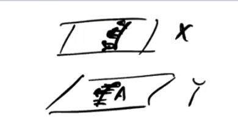

Image

There are some equivalent definitions of a morphism being étale:

- Smooth of relative dimension zero
- Locally finite presentation and *formally étale*
- Locally *standard étale*, i.e. for each $x\in X$ with $y\mathrel{\vcenter{:}}= f(x)$, there exists a $U\ni x, V\ni y$ such that $f(U) \subseteq V$ and $V=\operatorname{Spec}(R), U = \operatorname{Spec}\qty{R[x]_h / g}$ (where we localize at $h$) such that the derivative $g'$ is a unit in $R[x]_h$ and $g$ is monic.

For this last definition, thinking of $\operatorname{Spec}(R[x])$ as $R\times {\mathbb{A}}^n$, what happens when modding out by a polynomial $g$? This yields a curve cutting out the roots of $g$. Inverting $h$ deletes the locus where $h$ vanishes, and $g'$ being a unit means that the $g$ has no double roots in the fibers. In other word, the deleted locus passes through all double roots:

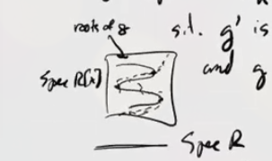

Image

Check that standard étale morphisms are étale, and try to understand the proof that all étale morphisms are locally standard étale.

- Multiplication by $[n]$ on an elliptic curve if $n \in {\mathbb{Z}}$ is invertiable in the base field.
- Take ${\mathbb{G}}_m = \operatorname{Spec}k[t, t^{-1}]$, and the map \begin{align*} {\mathbb{G}}_m &\to {\mathbb{G}}_m \\ t^m &\mapsfrom t ,\end{align*} where $n$ is prime to $\operatorname{ch}(k)$.[^7]

Show that the last map above is étale.

*(Hint: use the fact that ${\frac{\partial }{\partial t}\,} (t^n) = nt^{n-1}$, which is a unit.)*

Consider the map
$$\begin{align*}
{\mathbb{G}}_m &\hookrightarrow{\mathbb{A}}^1 \\
k[t, t^{-1}] &\mapsfrom k[t]
.\end{align*}
We need to check 3 things:$$

- Locally finite presentation,
  - This is a finitely presented ring map, since you just need to adjoin an inverse of $t$, one element and one relation.
- Flat,
  - Since open embeddings are flat,
- $\Omega^1_{{\mathbb{G}}_m / {\mathbb{A}}^1} = 0$,
  - True for a Zariski open embedding.

Note that this is finite onto its image.

Any open immersion is étale.

Note that we actually already checked this!

Use the fact that ${\mathbb{G}}_m$ is ${\mathbb{A}}^1\setminus\left\{{\mathbf{0}}\right\}$, so take ${\mathbb{G}}_m \setminus\left\{{1}\right\}$ and the map
$$\begin{align*}
{\mathbb{G}}_m\setminus\left\{{1}\right\} &\to {\mathbb{G}}_m \\
t^2 &\mapsfrom t
.\end{align*}$$

This is an étale surjection but not finite étale, since it is not proper. This also gives a counterexample to étale morphisms always looking like covering spaces, since here that may be true locally but doesn’t hold globally.

This is an important example to keep in mind, because you’ll often see arguments that treat étale maps as though they were finite onto their image.

Take a finite separable field extension, taking $\operatorname{Spec}$ of it yields an étale map.

Now for some non-examples:

Then the normalization $\tilde X\to X$ is not étale, since it is not flat.

Take the map
$$\begin{align*}
{\mathbb{A}}^1 &\to {\mathbb{A}}^1 \\
t^2 &\mapsfrom t
.\end{align*}$$

This is note étale since it is ramified at zero. We can compute
$$\begin{align*}
\Omega_f^1 = k[t]\, dt / d(t^2) = k[t] dt/ 2t\, dt
,\end{align*}
where \(2t\,dt\) does not generate this module. This is supported at \(t=0\) if \(\operatorname{ch}\neq 2\).$$

A finite flat morphism such that $\Omega_{X/Y}^1$ is not torsion: a hint is that the previous example almost works, with a slight modification. Let $\operatorname{ch}k = p$, and take
$$\begin{align*}
{\mathbb{A}}^1 &\xrightarrow{F} {\mathbb{A}}^1 \\
t^p &\mapsfrom t
.\end{align*}
Then \(\Omega_f^1 = k[t]\, dt / d(t^p) = k[t]\,dt\) since \(d(t^p) = 0\) in characteristic \(p\). This yields line bundles (?), so it is not torsion.$$

This map has a name: **the relative Frobenius**. In general, looking at Frobenii, the Kahler differentials will be very big. You might not be used to this: in characteristic zero, a map of relative dimension zero is generically étale. In this case, the Kahler differentials will always be torsion.

Consider a map
$$\begin{align*}
{\mathbb{A}}^m &\xrightarrow{f_1, \cdots, f_m} {\mathbb{A}}^m
,\end{align*}
since such a map is given by a system of \(m\) polynomials in \(m\) variables. Then \(f\) is étale is a neighborhood of \(\mathbf{a}\) if \(\det \qty{{\frac{\partial f_i}{\partial x_j}\,} \Big|_{\mathbf{a}} }\) is a unit.$$

### 2.3.1 Properties of Étale Morphisms

1. Open immersions are étale
2. Compositions of étale morphisms are étale[^8]
3. Base change of étale morphisms are étale, i.e.

[figure not shown]

4. There is a 2 out of 3 property: If $\phi \circ \psi$ and $\phi$ are étale, then $\psi$ is étale.

Show property 4 above.

Étale morphisms on varieties over an algebraically closed field induce isomorphisms on complete local rings at closed points.

Prove this! Hint: use the criterion for formal étaleness. There’s an evident map one way on local rings coming from your étale morphism, and you need to produce the inverse map.

$\danger$ If $\psi$ is étale and $\phi\circ\psi$ is étale, it is not necessarily the case that $\phi$ is étale. Come up with an example!

Any property that can be checked at the level of complete local rings is true for the source of an étale morphism if it is true for the target.

Why? If you want to check a property for complete local rings on the source, note that the map induces an isomorphism of complete local rings.

## 2.4 Generalizing Topologies

### 2.4.1 Sites

The notion of a *site* will be a generalization of topological spaces and sheaves. The idea is we’ll generalize sheaf cohomology to this setting. On a nice space like a manifold, singular cohomology is isomorphic to the sheaf cohomology of the constant sheaf $\underline{{\mathbb{Z}}}$. Here we’ll find some version of a sheaf where étale cohomology with ${\mathbb{Z}}/\ell^n{\mathbb{Z}}$ coefficients will be the sheaf cohomology with the constant sheaf $\underline{{\mathbb{Z}}/\ell^n{\mathbb{Z}}}$.

What parts of the definition of a topological space are needed to define the notion of a sheaf?

Recall that the *sheaf condition* is given in two parts:

1. A section is determined by its value on a cover, and
2. Sections can be glued when they agree on intersections.
1. As in presheaves, a notion of open sets and inclusions. (I.e., a category of open sets.)[^9][^10]

We’d also like to make sense of the sheaf condition:

2. Collections of morphisms which are “covers,” remembering which collections of opens cover a space, and
3. The existence of certain fiber products (intersections).

The motivation for (3) above is that for $U, V \subseteq X$, we can form $U\times V = U\cap V$.

We will make the following preliminary definition:

A category $\mathcal{C}$ with a collection of *covering families*[^11]
$$\begin{align*}
\left\{{X_\alpha \xrightarrow{f_\alpha} X {~\mathrel{\Big|}~}\alpha\in A}\right\}
\end{align*}
such that several axioms are satisfied.$$

We’ll discuss the axioms next time, they just capture the notion of what a cover of a topological space should look like.

There are at least three different notions of this definition! The one above is perhaps the least general but the easiest to work with.

For $X$ a topological space, $\mathcal{C}$ the category of open sets in $X$, then $\left\{{U_\alpha\to U}\right\}$ is a covering family if the $U_\alpha$ cover $U$, i.e. $U = \cup_\alpha U_\alpha$.

Let $M$ be a manifold and $\mathcal{C}$ be the category of manifolds over $M$, so all $M' \xrightarrow{f} M$ such that $f$ is locally an isomorphism. Note that these are smooth local homeomorphisms. Let
$$\begin{align*}
\left\{{M_\alpha \xrightarrow{f_\alpha} M}\right\} \text{ if } \bigcup_\alpha \operatorname{im}(f_\alpha) = M
\end{align*}$$

Let $X$ be a scheme and consider $X_{\text{et}}$ the category of all étale $Y/X$: so the objects are schemes $Y$ admitting an étale morphism $Y\to X$. Then $\left\{{X_\alpha\to X}\right\}$ is a covering family if $\cup\operatorname{im}(f_\alpha) = X$.

This will be the fundamental object, and we’ll define étale cohomology by defining sheaves on this category, taking a constant sheaf $\underline{{\mathbb{Z}}/\ell^n{\mathbb{Z}}}$, and we’ll take sheaf cohomology.

# 3 Lecture 3

## 3.1 Defining Sites

Today: we’ll discuss sites, which generalizes the category of open sets over a topological space. The goal is to generalize spaces and sheaves to categories, and to define a sheaf we need

1. A notion of a *cover*, and
2. A notion of intersections/fiber products of open sets.

A **Grothendieck topology** on $\mathcal{C}$ or a **site** on $\mathcal{C}$ is the data of for each $X\in \mathrm{Ob}(\mathcal{C})$ a collection of sets of morphism $\left\{{X_\alpha \to X}\right\}$ (*covering families*) satisfying

- Intersections exist: If $X_\alpha\to X$ appears in a covering family and $Y\to X$ is arbitrary, the fiber product $X_\alpha\times_X Y$ exists.
- Intersecting with a cover again yields a cover: If $\left\{{X_\alpha\to X}\right\}$ is a covering family and $Y\to X$ is arbitrary, then the covering family can be pulled back: $\left\{{Y\times_X X_\alpha\to Y}\right\}$ is again a covering family.[^12]
- Compositions of coverings are again coverings: If $\left\{{X_\alpha\to X}\right\}_{\alpha}$ and $\left\{{X_{\alpha\beta} \to X_\alpha}\right\}_{\alpha,\beta}$ are covering families, then you can compose, i.e. taking the set of all possible ways of composing $\left\{{X_{\alpha\beta} \to X_\alpha \to X}\right\}$ is again a covering family.[^13]
- Isomorphisms are covers: If $X\xrightarrow{\sim_f} Y$ is an isomorphism, then the singleton family $\left\{{X\xrightarrow{f} Y}\right\}$ is a covering family.

### 3.1.1 Examples of Sites

If $X$ is a topological space, define $\mathcal{C}$ whose objects are open subsets of $X$ where there is a unique morphism $U\to V$ iff $U\subseteq V$. Then $\left\{{U_\alpha \to U}\right\}$ is a covering family if $\bigcup_\alpha U_\alpha = U$.

Let $X$ be a scheme, and define the small étale site $X_{\text{ét}}$: the category whose objects are étale morphisms $Y\xrightarrow{f} X$ where morphisms are maps over $X$:

[figure not shown]

Note that $g$ is étale by the 2 out of 3 property.

Then $\left\{{X_\alpha\to X}\right\}$ is a covering family if the set theoretic images satisfy $\bigcup_\alpha \operatorname{im}(f_\alpha) = X$.

Again let $X$ be a scheme, and define $X_{\mathrm{Et}}$ the category whose objects are all $X{\hbox{-}}$schemes (where we no longer require the maps to be étale). In other words, this is the overcategory of $X$: the category of schemes over $X$. Then $\left\{{U_\alpha\xrightarrow{f_\alpha}U}\right\}$ is a covering family if all of the $f_\alpha$ are étale and $\bigcup_\alpha \operatorname{im}(f_\alpha) = U$.

Note the difference: in the small site, we included only étale $X{\hbox{-}}$schemes, vs all $X{\hbox{-}}$schemes in the big site. In both cases, the notion of covering families are the same.

Let $X$ be a complex analytic space (e.g. a complex manifold), then there is an analytic étale site whose objects are complex analytic spaces $Y\xrightarrow{f} X$ such that locally on $Y$, $f$ is an analytic isomorphism. Note that this includes covering spaces. The morphisms will be morphisms over $X$ creating commuting triangles, and the covers are the usual covers.

This category is part of what motivates the definition of the étale topology. This is what we’re trying to imitate. E.g. if you have a complex algebraic variety, taking its analytification will be one of these. This site will show up later when we compare étale cohomology to singular cohomology.

We haven’t said what it means to be a sheaf yet, but Grothendieck topologies behave in somewhat unexpected ways. The category of sheaves of the analytic étale cohomology, ${\operatorname{Sh}}(X_{\mathrm{an{\hbox{-}}et}})$, is canonically equivalent to ${\operatorname{Sh}}(X^{\mathrm{top}})$. Thus sometimes the category of sheaves over a site doesn’t remember the site, i.e. two different sites can have the same category of sheaves. On the RHS we had a category of open subsets, whereas on the LHS we included things like covering spaces. We’ll see later that there is a notion of morphisms of sites, and there is a morphism inducing this equivalence.

Proving this isomorphism will be an exercise, here’s an outline of why it’s true: suppose you have a cover of $X$ in this category, i.e. a family of local analytic isomorphisms. Given any of these, you can cover by subsets for which these are isomorphisms onto their images.

The letter **fppf** stand for **faithfully flat and finite presentation**.[^14]

There are small and big sites here: we define $X_{\mathrm{\operatorname{fppf}}}$ whose objects are fppf morphism $Y\to X$, with morphisms as triangular diagrams of morphisms over $X$, and covers are the usual covers. Note that replacing fppf morphisms with flat morphisms would yield an equivalent definition here.

If $X$ is a scheme, then the small Zariski topology is $X_{\mathrm{zar}}$ whose objects are ${\operatorname{Op}}(X^{\mathrm{top}})$, the Grothendieck topology of the corresponding topological space, and we take the usual notion of covers. There is a big Zariski topology $X_{\mathrm{Zar}}$ whose category is all $X{\hbox{-}}$schemes $\left\{{U_\alpha\xrightarrow{f_\alpha} U}\right\}$ with $f_\alpha$ open embeddings and $\bigcup_\alpha \operatorname{im}(f_\alpha) = U$.

Some other examples:

- The **Nisnevich** topology, which lives between the Zariski and the étale topology,
- The **crystalline** site, used to define crystalline cohomology,
- The **infinitesimal** site,
- The **cdh** topology, the **arc** topology, the **rh** topology, and many more.

## 3.2 Toward Sheaves of Sites

For $\mathcal{D}$ a category, a $\mathcal{D}{\hbox{-}}$valued **presheaf** is a contravariant function $F:\mathcal{C}\to \mathcal{D}$.

This makes no reference to any Grothendieck topology.

If $X$ is a topological space, a $\mathcal{D}{\hbox{-}}$valued presheaf of $X$ is equivalent to a presheaf on ${\operatorname{Op}}(X)$.

We can now define a sheaf. What’s the motivation? For $X$ a topological space, it’s a sheaf satisfying some conditions: its sections are determined by an open cover, and given sections agreeing on overlaps allows gluing. This can be captured by a specific diagram, which is what we will use here.

Recall the definition of a **site** (): in short, a category equipped with the Grothendieck topology.

A **sheaf** $F$ is presheaf such that

[figure not shown]

is an *equalizer* diagram for all covering families $\left\{{U_\alpha \to U}\right\}$.

The diagram arises due to the fact that if we have a bunch of maps coming from a cover, since we have a contravariant functor, we get a map into the product. We then look at the intersections of all $U_{\alpha}, U_{\alpha'}$.

The two arrows occurring come from the projections:

[figure not shown]

where we use the fact that since $F$ is a contravariant functor, it induces maps going the other way.

What does being an equalizer mean, say if $F$ is set-valued? “Exactness” at the middle term is the gluing condition, and exactness at the first term is injectivity, i.e. a section (the values of $F$ on $U$) are determined by its values on a cover (by $F(U_\alpha)$). Note that in fact $F(U)$ is the limit of this diagram. The gluing condition is more precisely that if we’re given $(s_\alpha) \in \prod_\alpha F(U_\alpha)$ such that $F(\pi_1)(s_\alpha) = F(\pi_2)(s_\alpha)$, then $(s_\alpha)$ comes from $F(U)$.

A **morphism** $F_1\to F_2$ of either presheaves or sheaves is a natural transformation of functors.

### 3.2.1 Examples of Sheaves of Sites

Any representable functor is a sheaf on the étale site $X_{\text{Ét}}$. In fact, any such functor is a sheaf on the big fppf site $X_{\mathrm{\operatorname{Fppf}}}$: the category of all $X{\hbox{-}}$schemes with covers as fppf covers, which are maps that are flat and jointly surjective.

Take $\mu_n$ the functor represented by $\mu_n \mathrel{\vcenter{:}}=\operatorname{Spec}k[t] / t^{n-1}$. For $U$ an $X{\hbox{-}}$scheme, we can evaluate in the following way:
$$\begin{align*}
\mu_n(U) = \left\{{f\in {\mathcal{O}}_U(U) {~\mathrel{\Big|}~}f^n = 1}\right\}
.\end{align*}$$

We define a sheaf of the étale site as ${\mathcal{O}}^{\text{ét}}_X(U) = {\mathcal{O}}_U(U)$ where we’ve said what the values are. This is a sheaf that is represented by ${\mathbb{A}}^1_{/X}$.

The constant sheaf $\underline{\mathbb{Z}/\ell^n\mathbb{Z}}$. How can we prove it is a sheaf, given the theorem, and determine what its values are? This is represented by $\qty{\mathbb{Z}/\ell^n\mathbb{Z}} \times X$, i.e. taking the disjoint union of $\ell^n$ copies of $X$. The values are given by
$$\begin{align*}
\underline{\mathbb{Z}/\ell^n\mathbb{Z}}(U) = \hom_{{\operatorname{Top}}}(U^{{\operatorname{Top}}}, \mathbb{Z}/\ell^n\mathbb{Z})
,\end{align*}
where we give the set \(\mathbb{Z}/\ell^n\mathbb{Z}\) the discrete topology and take morphisms to be continuous maps.$$

The constant sheaf $\underline{S}$ doesn’t associate $S$ to every open set: it instead associates $S^d$ where $d$ is the number of components. The former would only be a presheaf, and not a sheaf.

We can take the sheaf ${\mathbb{G}}_m(U) \mathrel{\vcenter{:}}={\mathcal{O}}_U(U)^{\times}$, whose values are obtained by taking the global sections of the structure sheaf and only keeping the units. This is represented by
$$\begin{align*}
{\mathbb{G}}_{m, X} = \operatorname{Spec}{\mathbb{Z}}[t, t^{-1}] \underset{\scriptscriptstyle {\operatorname{Spec}{\mathbb{Z}}} }{\times} X
\end{align*}
Why does this represent this functor? Mapping into this requires that \(t\) goes to an invertible function, which yields the isomorphism.$$

Note that all of these functors take values in abelian groups, which is a consequence of the fact that the representing objects are group schemes. In fact, one definition of a group scheme is that the functor it represents factors through groups.

Take the functor ${\mathbb{P}}^n(U) \mathrel{\vcenter{:}}=\hom(U, {\mathbb{P}}^n)$. This functor can be written down as a line bundle on $U$ with a surjective map from ${\mathcal{O}}_U \to {\mathcal{O}}_U^n$ (?), the functor represented by projective space, and that’s also a sheaf that is necessarily representable but not an abelian one.

Some things we still need to get to:

- A proof that $\underline{\mathbb{Z}/\ell^n\mathbb{Z}}$ is actually a sheaf,
- A proof that the category of sheaves on the big étale site $X_\text{Ét}$[^15] with values in $\mathbf{Ab}$ is abelian and has enough injectives.

## 3.3 Étale Cohomology: A Preliminary Definition

Let $\mathcal{F}$ be a sheaf and define a functor $\Gamma_X: \mathcal{F}\to \mathcal{F}(X)$ sending it to its values on $X$. Then the **étale cohomology** of $X$ is defined by
$$\begin{align*}
H^i(X_\text{ét}, \underline{\mathbb{Z}/\ell^n\mathbb{Z}}) \mathrel{\vcenter{:}}= R^i \Gamma_X(\underline{\mathbb{Z}/\ell^n\mathbb{Z}})
,\end{align*}
the right-derived functors of \(\Gamma_X\).$$

This definition is incomplete, and in particular, it’s highly non-obvious that this category of abelian sheaves is abelian. E.g. usually when proving that the category of abelian sheaves on a topological space has cokernels, you use sheafification: you take the cokernel of a map of presheaves, which is a presheaf, and sheafify it. Here, we don’t know how to sheafify a presheaf on a site. The usual construction involves forming the *espace étalé* and taking sections does not work for a site, you need a genuinely different argument.

Even showing cokernels exist in the category of abelian sheaves on a site is nontrivial. Try as an exercise!

What will be true in general is that this category will be an $AB5$ abelian category, and having enough injectives is all that’s additionally needed. This comes from machinery developed in Grothendieck’s Tohoku paper, and we’ll sketch part of the proof.

Properties of these sheaves are not so obvious, and depend on the site you’re working over:

Consider the map
$$\begin{align*}
{\mathbb{G}}_m &\to {\mathbb{G}}_m \\
t^m &\mapsfrom t
,\end{align*}
where \(n\) is invertible over the base, e.g. if we’re over a field of characteristic coprime to \(n\). This yields a map of sheaves in two different settings. In \(X_{\mathrm{Zar}}\) we have
\begin{align*}
{\mathcal{O}}^{\times}&\to {\mathcal{O}}^{\times}\\
f &\mapsto f^n
.\end{align*}$$

We can look at this in $X_{\text{ét}}$, yielding
$$\begin{align*}
{\mathcal{O}}_\text{ét}^{\times}&\to {\mathcal{O}}_\text{ét}^{\times}\\
f &\mapsto f^m
.\end{align*}$$

This map is not an epimorphism on $X_{\mathrm{Zar}}$ but is on $X_{\text{ét}}$

It suffices to give one example: take $X = \operatorname{Spec}{\mathbb{R}}$ and $n=2$, and since this is just a point, the sheaf is determined by its values. So is the map
$$\begin{align*}
{\mathbb{R}}^{\times}&\to {\mathbb{R}}^{\times}\\
t &\mapsto t^2
\end{align*}
surjective? The answer is no, of course, since its image is \({\mathbb{R}}_{\geq 0}\).$$

This will be surjective on $X_{\text{ét}}$ if $n$ is invertible on $X$. If we were in usual topological spaces, we would want to show that given any section of the sheaf on an open set, it can be refined. Here we want to pass to an étale cover so that section has an $n$th root. So given $f\in {\mathbb{G}}_m(U)$, we want an étale cover of $U$ so that $f$ obtains an $n$th root. An invertible function is a map $U\to {\mathbb{G}}_m$, and we can form the square

[figure not shown]

The RHS map is étale since $n$ is invertible, and the fiber product is étale since étale morphisms are preserved by base change.

$f$ has an $n$th root upstairs. (Verify!)

There’s a more concrete way of writing this: note that ${\mathbb{A}}^1_{U, z} = \operatorname{Spec}k[t]$, so take the subscheme cut out by $V(z^n - f)$. This will be an étale cover of $U$ (the same one in fact) and $z$ is now an $n$th root.

Check the details! Namely that this argument implies that this map of sheaves is an epimorphism.

This map of sheaves ${\mathbb{G}}_m \xrightarrow{z^m \mapsfrom z} {\mathbb{G}}_m$, noting that if $n$ is not invertible this will not be an epimorphism, will always be an epimorphism in ${\operatorname{Sh}}(X_\mathrm{\operatorname{fppf}})$ since this map is flat and finitely presented.

## 3.4 Preview: Morphisms of Sites

Suppose $T_1, T_2$ are sites (categories with covering families), then a **continuous map of sites** $f:T_1 \to T_2$ is a functor $T_2 \to T_1$[^16] that preserves fiber products and sends covering families to covering families.

A continuous map $f\in {\operatorname{Hom}}_{\operatorname{Top}}(X, Y)$ induces a map
$$\begin{align*}
{\operatorname{Op}}(Y) &\to {\operatorname{Op}}(X) \\
U &\mapsto f^{-1}(U)
.\end{align*}$$

Check that this is a continuous map of sites.

Next time: a bunch of examples.

# 4 Lecture 4: Descent

Last time: sites, sheaves, and morphisms of sites. Today: descent, which is how we’ll see that many familiar objects are sheaves on the étale site, such as representable functors or quasicoherent sheaves.

## 4.1 Reminder

Given two sites $(C, T_1)$ and $(D, T_2)$ where $C, D$ are categories and the $T_i$ are collections of covering families, a **morphism** is a functor $f^{-1} :D\to C$ such that

1. $f^{-1}$ preserves fiber products.
2. $f^{-1}$ sends covering families to covering families.

The main example: for $f:X\to Y$ a map of topological spaces, the functor $F: {\operatorname{Op}}(Y) \to {\operatorname{Op}}(X)$ given by $F(U) \mathrel{\vcenter{:}}= f^{-1}(U)$ sending an open set to its preimage.

Check that this is a continuous map of sites.

Suppose $X$ is a scheme, then there is a natural map of sites from $X_{\mathrm{\operatorname{Fppf}}}$ (all $X{\hbox{-}}$schemes where covers are collections of jointly surjective flat morphism) to $X_{\text{Ét}}$ (all $X{\hbox{-}}$schemes where covers are jointly surjective étale morphisms) to $X_{\text{ét}}$ (étale $X{\hbox{-}}$schemes with morphisms over $X$) to $X_{{\mathrm{zar}}}$ (the open subsets of $X$ with morphisms given by inclusions and covers the usual covers). The maps here are inclusions going the other way.

Check that these are continuous maps of sites.

On terminology:

- What we’ve been calling a site or a Grothendieck topology is sometimes called a *Grothendieck pretopology*. The major difference is that you don’t have to assume the existence of fiber products.
- You may also see the notion of a **topos**, which is the category of sheaves on a site.

## 4.2 Setting up Descent

1. We’ve said what it means to be a sheaf on a site, how do we check that a given functor is a sheaf on $X_{\text{ét}}$ or $X_{\mathrm{\operatorname{fppf}}}$?
2. How do we construct such sheaves?
1. If $Y$ is an $X{\hbox{-}}$scheme (i.e. a scheme equipped with a map to $X$) then the functor $Z \to \hom_X(Z, Y)$ is a sheaf on $X_{\mathrm{\operatorname{Fppf}}}, X_{\text{Ét}}, X_{\text{ét}}$, etc.
2. Suppose $\mathcal{F}$ is a quasicoherent sheaf on $X$, so $\mathcal{F}\in {\mathrm{QCoh}}(X)$, the functor of taking global sections:

[figure not shown]

is a sheaf on $X_{\mathrm{\operatorname{Fppf}}}, X_{\text{Ét}}, X_{\text{ét}}$, etc.

The sheaf associated to the above functor on $X_{\text{ét}}$ will be denoted $\mathcal{F}^\text{étale}$.

Suppose we have an fppf cover of $X$

[figure not shown]

Suppose $\mathfrak{F}\in {\mathrm{QCoh}}(X)$. When does it come from a quasicoherent sheaf on $X$? I.e., when is there a quasicoherent sheaf $\mathcal{F}'$ on $X$ and an isomorphism between its pullback to $U$ and $\mathcal{F}$? What extra structure do you need to “descend” to ${\mathrm{QCoh}}(X)$, i.e. to pick such an isomorphism?

Given $\mathcal{F}_1, \mathcal{F}_2 \in {\mathrm{QCoh}}(U)$ and a morphism $f: { \left.{{\mathcal{F}_1}} \right|_{{U}} } \to { \left.{{\mathcal{F}_2}} \right|_{{U}} }$, when does $f$ come from $X$?

If $X = \operatorname{Spec}k$ and $U$ is a finite separable extension, then this question is exactly what Galois descent is about!

$U = {\coprod}U_i \to X$ is a Zariski cover. If we have a sheaf on $U$, what extra data do we need to get a sheaf on $X$? We need isomorphisms ${ \left.{{\mathcal{F}_i }} \right|_{{U_i\cap U_j}} } \xrightarrow{\sim} { \left.{{\mathcal{F}_j}} \right|_{{U_i\cap U_j}} }$ (gluing data) where each $\mathfrak{F}_i$ is the sheaf given on $U_i$. We also need a cocycle condition on triple intersections. Given this data, gluing yields a sheaf on $X$. This may be familiar from vector bundles. Thus to give a sheaf, it suffices to specify gluing data.

Morphisms $\mathcal{F}\to \mathcal{G}$ is the same as morphisms ${ \left.{{\mathcal{F}}} \right|_{{U_i}} } \to { \left.{{\mathcal{G}}} \right|_{{U_i}} }$ which commute with the gluing data. We’d like to generalize this notion of commuting with gluing data to more general types of covers.

Suppose $U\xrightarrow{f}X$ is a morphisms, then **descent data** for a quasicoherent sheaf on $U/X$ is the following:

1. A sheaf $\mathcal{F}\in {\mathrm{QCoh}}(U)$.
2. Gluing data: If we take the fiber product of $U$ with itself, mapping to $U$ under 2 different projections[^17],

[figure not shown]

there are isomorphisms
$$\begin{align*}
\phi: \pi_1^* \mathcal{F} \xrightarrow{\sim} \pi_2^* \mathcal{F}
.\end{align*}$$

3. Cocycle condition: in the following fiber product

[figure not shown]

we have $\pi_{23}^* \phi \circ \pi_{12}^* \phi = \pi_{13}\phi$.

Check that this agrees with the previous notions when $U\to X$ is a Zariski cover.

Given descent data $(\mathcal{F}, \phi)$ and $(\mathcal{G}, \psi)$, a **morphism** is a morphism $h: \mathcal{F} \to \mathcal{G}$ of quasicoherent sheaves on $U$ such that the following diagram commutes:

[figure not shown]

## 4.3 Descent Data is Equivalent to Quasicoherent Sheaves

Suppose $f: U\to X$ is fppf. Then $f^*$ induced an equivalence of categories between ${\mathrm{QCoh}}(X)$ and descent data on $U/X$.

This doesn’t quite make sense, since we haven’t covered how to get descent data from a given sheaf. Explicitly, given $\mathcal{F}\in {\mathrm{QCoh}}(X)$, we can pullback to obtain $f^* \mathcal{F}\in {\mathrm{QCoh}}(U)$. We now want an isomorphism
$$\begin{align*}
\qty{f\circ \pi_1}^* \mathcal{F} \xrightarrow{\sim} \qty{f\circ \pi_2}^* \mathcal{F}
\end{align*}
on \(U\times_X U\). We have a situation like the following:$$

[figure not shown]

Since $f\circ \pi_1 = f\circ \pi_2$ in this case, pulling back the identity yields the desired isomorphism.

Let $U = {\coprod}U_i$ be a Zariski cover of $X$, then vector bundle can be obtained from ${\mathcal{O}}_{U_i}^{\oplus n}\in {\mathrm{QCoh}}(U_i)$. To glue this to a vector bundle on $X$, we need isomorphism $\phi_{ij} {\mathcal{O}}_{U_i\cap U_j}^{\oplus n} \xrightarrow{\sim } {\mathcal{O}}_{U_i\cap U_j}^{\oplus n}$ such that ${ \left.{{\phi_{jk}}} \right|_{{U_i \cap U_j \cap U_k}} } \circ { \left.{{\phi_{ij}}} \right|_{{U_i \cap U_i \cap U_k}} } = { \left.{{\phi_{ik}}} \right|_{{U_i\cap U_j \cap U_k}} }$. For $n=1$, this is gluing data for a line bundle.

Suppose $L/k$ is a Galois extension with Galois group $G$, then $\operatorname{Spec}L \to \operatorname{Spec}k$ is an étale cover. Descent data on this map is a quasicoherent sheaf on $\operatorname{Spec}L$, i.e. an $L{\hbox{-}}$vector space $V$, with an isomorphism $\pi_1^* V \xrightarrow{\phi \sim}\pi_2^* V$ satisfying the cocycle condition. We can compute
$$\begin{align*}
\operatorname{Spec}L \times_{\operatorname{Spec}k} \operatorname{Spec}L = \operatorname{Spec}L\otimes_k L = {\coprod}_{L\xrightarrow{\sim} L} \operatorname{Spec}L
,\end{align*}
which is a torsor for the Galois group, and in fact is equal to \({\coprod}_{\operatorname{Gal}(L/k)} \operatorname{Spec}L\).$$

Convince yourself that descent data here is the same as Galois descent, i.e. a semilinear action.

*(Hint: you will need to use $\phi$.)*

Explicitly, the theorem says

- Given a morphisms of descent data, we get a unique morphism of sheaves (fully faithful)
- If you have descent data, it comes from a sheaf (essentially surjective)

So we need to prove

1. $f^*$ is fully faithful, inducing an isomorphism on hom sets, and
2. $f^*$ is essentially surjective.

> Reference: Neron modules by BLR.

### 4.3.1 Proof of Theorem

Given $\mathcal{F}_1, \mathcal{F}_2 \in {\mathrm{QCoh}}(X)$, then we have a functor and thus a map
$$\begin{align*}
\hom_X(\mathcal{F}_1, \mathcal{F}_2) \xrightarrow{f^*} \hom_U(f^*\mathcal{F}_1, f^*\mathcal{F}_2)
\end{align*}
We’re not trying to show this map is a bijection, since we need more than that: the morphism should commute with the descent data. We can produce two maps to fill in the following diagram:$$

[figure not shown]

where these hom sets are equal since $f\circ \pi_1 = f\circ \pi_2$.

Given $g\in {\operatorname{Hom}}_U(f^* \mathcal{F}_1, f^* \mathcal{F}_2)$, this is a morphism of descent data if maps to the same element under $\pi_1^*$ and $\pi_2^*$ using the above identification of hom sets.

This follows from definitions, check that it holds.

Being fully faithful is the same as the above diagram being a equalizer. I.e., the first map $f^*$ is injective, yielding faithfulness, and fullness means that any map in the middle that has the same image under the two arrows $\pi_1^*, \pi_2^*$ comes from an element in $\hom_X(\mathcal{F}_1, \mathcal{F}_2)$.

Assuming that this is fully faithful, why do quasicoherent sheaves give sheaves on $X_{\text{ét}}$ or $X_{\mathrm{\operatorname{fppf}}}$? Being a sheaf was characterized by an equalizer diagram gotten by replacing the first hom with taking global sections of $\mathcal{F}$ on $X, U, U\times_X U$.

Taking $\mathcal{F}_1 = {\mathcal{O}}$ and $\mathcal{F}_2 = \mathcal{F}$, this shows that $\mathcal{F}^{\text{ét}}$ (resp. $\mathcal{F}^{\mathrm{\operatorname{fppf}}}$) is a sheaf. In this case, the first hom is global sections of $\mathcal{F}$ on $X$, the middle are global sections of $\mathcal{F}$ on $U$, and the two maps are to the double intersections.

To prove this is an equalizer diagram, we’ll need a lemma:

Suppose $R\to S$ is a faithfully flat ring morphism (flat and morphisms on spec are surjective) and suppose $N\in {R{\hbox{-}}\operatorname{mod}}$. Then there is an equalizer diagram

[figure not shown]

This is the case where $\mathcal{F}_1 = {\mathcal{O}}$ and $\mathcal{F}_2 = \tilde N$ the quasicoherent sheaf associated to $N$, $U = \operatorname{Spec}S \to X = \operatorname{Spec}R$.

**Step 1**: (Amazing trick) WLOG $R\to S$ splits, so there’s a map $S\to R$ such that $R\to S\to R$ is the identity. We can tensor with $S$, i.e. push out this map along itself to obtain

[figure not shown]

where $m$ is a section given by multiplication.

The claim is that we can replace $R$ with $S$ and $S$ with $S\otimes_R S$.

Checking the equalizer diagram is the same as showing that the following sequence is exact:
$$\begin{align*}
0 \to N \to N\otimes_R S \xrightarrow{f-g} N\otimes_R S\otimes_R S
,\end{align*}
where \(f, g\) are the maps given in the equalizer. It suffices to do this after tensoring with \(S\), since a sequence of \(R\) modules is exact iff it is exact after tensoring with \(S\). One direction is easy, since \(S\) is flat, and the other direction follows from the fact that you can check on each stalk, and after tensoring the stalks are the same. This requires checking for each point on \(\operatorname{Spec}R\) that the map on stalks is exact, but that’s true because we have a surjective map and this can be checked upstairs.$$

**Step 2**: Suppose $R\xrightarrow{f} S$ splits via a map $S\xrightarrow{r} S$. The geometric picture is that we’re supposing we have a section to $U\to X$, and descending amounts to pulling back along the splitting. We first want to check that $N\to N\otimes_R S$ is injective, which is true since we can use the map $\operatorname{id}_N \otimes r$ to produce a splitting. Why is this true? Supposing $n\in N$ maps to zero, then noting that $N\to N\otimes_R S \to N$ is the identity and thus maps $f(n)\xrightarrow{\operatorname{id}} 0$, forcing $n=0$.

We now want to show exactness in the middle. Define
$$\begin{align*}
\tilde r: S\otimes_R S &\to S \\
s_1 \otimes s_2 &\mapsto s_1 \cdot f(r(s_2))
\end{align*}
Suppose we have something in the image of the differential. This yields
\begin{align*}
\operatorname{id}_N \otimes\tilde r \qty{n\otimes s\otimes 1 - n\otimes 1 \otimes s}
= n\otimes s - n\otimes f(r(s))
= n\otimes s - nr(s) \otimes 1
.\end{align*}$$

Thus $n\otimes s\otimes 1 - n\otimes 1\otimes s = 0$, putting this in the kernel of the differential, making the last term above equal to zero, and thus $n\otimes s = n r(s) \otimes 1$, which is in the image of the differential. So anything in the kernel is in the image, where we’ve proved it for pure tensors, and it’s an exercise to do it in general.

Given $R\to S$ faithfully flat, you can define the **Amitsur complex**:
$$\begin{align*}
N \to N\otimes S \to N\otimes S^{\otimes 2} \to \cdots \to N\otimes S^{\otimes r}
,\end{align*}
where the maps are given by alternating sums of identities with a 1 in the \(i\)th spot. There is a theorem that this is always exact, essentially by the same proof as above: reduce to the case where you have a section by tensoring with \(S\), then use the section to build a nullhomotopy.$$

> Next time: we’ll complete the proof of fppf descent.

# 5 Lecture 5

Last time: we started fppf descent, and wanted to show the quasicoherent sheaves and representable functors give sheaves on $X_{\text{ét}}$ and $X_{\mathrm{\operatorname{fppf}}}$. Given a quasicoherent sheaf, we take the associated presheaf on the étale site given by taking the values of its pullback to any object on the étale site. This yields a sheaf on the étale site, and we’ll also conclude that representable functors yield such sheaves as well.

## 5.1 Continuation of Proof

Reminder of the theorem (fppf descent for quasicoherent sheaves): If $f:U\to X$ is an fppf cover, so finitely presented and faithfully flat, then the pullback $f^*$ induces an equivalence of categories ${\mathrm{QCoh}}(X)$ to descent data for quasicoherent sheaves relative to $U/X$. This descent data is a quasicoherent sheaf on $U$, so you can take its 2 pullbacks to $U\times_X U$ (thinking of these as the double intersections of objects in the cover) which admit an isomorphism between them which needs to satisfy a cocycle condition on $U\times_X U \times_X U$. For Zariski covers, this reduces to having a cover by opens, a sheaf on each objects, and gluing data that satisfies the usual cocycle condition.

The goal was to prove (1) this functor is fully faithful, so the map on hom sets is a bijection. Given $\mathcal{F}_1, \mathcal{F}_2 \in {\mathrm{QCoh}}(X)$, we wanted a certain diagram to be an equalizer. Faithfulness is the injectivity of the first map $f^*$, and fullness is showing that elements go to the same place in the next two maps.

We proved a lemma: if $R\to S$ is a faithfully flat ring map and $M\in {R{\hbox{-}}\operatorname{mod}}$ then

[figure not shown]

is an equalizer diagram. We used one of Daniel’s favorite tricks in fppf descent: producing a section by base-changing to $S$.

### 5.1.1 Proof of Full Faithfulness

**Step 1**: Reduce to the case where $U\to X$ is affine.

*(Hint: See chapter 6 of Neron models. This will use that the map has finite presentation, and in fact even less, that the map is quasicompact.)*

**Step 2**: We now have $R\to S$ faithfully flat, where we’re thinking of $U = \operatorname{Spec}S, X = \operatorname{Spec}R$. Since $N, M \in {R{\hbox{-}}\operatorname{mod}}$, after replacing symbols, we want the following diagram to be an equalizer:

[figure not shown]

where all tensors are over $R$. The first map takes a map $f:M\to N$ and composes with the map $N\to N\otimes S$ from the lemma to get a map $M\to N\otimes S$, which automatically extends to a map $M\otimes S \to N\otimes S$. Exactness in the middle also comes from the lemma. Alternatively, injectivity of the first map follows from injectivity of $N\to N\otimes S$ and left-exactness of $\hom(M, {\,\cdot\,})$, as does exactness everywhere else.

A short diversion:

For $\mathcal{F}\in {\mathrm{QCoh}}(X)$, we defined $\mathcal{F}^{\text{ét}} \in {\operatorname{Presh}}(X_{\text{ét}})$ where $\mathcal{F}^{\text{ét}}(U\xrightarrow{\pi }X) \mathrel{\vcenter{:}}=\pi^* \mathcal{F}(U)$ is a sheaf on $X_{\text{ét}}$ and $X_{\mathrm{\operatorname{fppf}}}$

We want to show that if $U\to V$ is an étale cover, we want

[figure not shown]

to be an equalizer diagram – but this is exactly the previous diagram where $\mathcal{F}\mathrel{\vcenter{:}}={\mathcal{O}}$ and $\mathcal{F}_2 \mathrel{\vcenter{:}}=\mathcal{F}$.

We have an étale sheaf ${\mathcal{O}}_{X}^{\text{ét}}: (U\to X) \mapsto \Gamma(U, {\mathcal{O}}_U)$.

### 5.1.2 Proof of Essential Surjectivity

We have $U\xrightarrow{f} X$ an fppf cover and descent data $(\mathcal{F}, \phi)$ on $U/X$ where $\mathcal{F}$ is a quasicoherent sheaf on $U$ and $\phi$ is an isomorphism between its two pullbacks to $U\times_X U$ satisfying the cocycle condition on $U\times_X U \times_X U$. We want some $\mathcal{G} \in {\mathrm{QCoh}}(X)$ such that the pullback admits an isomorphism $f^* \mathcal{G} \xrightarrow{\sim}\mathcal{F}$ for which the canonical descent data on the pullback agrees.

We’ll use a similar trick to construct $\mathcal{G}$.

**Step 1**: We’ll reduce to the case of an affine morphism.

**Step 2**:

Let $R\xrightarrow{f} S$ and $M\in {{S}{\hbox{-}}\operatorname{mod}}$. We’ll want an isomorphism $\phi: M\otimes_R S\to S\otimes_R M$ of $S\otimes_R S$ modules satisfying the cocycle condition. We make the following construction:

[figure not shown]

Suppose that $M$ is of the form $N\otimes S$ for $N\in {R{\hbox{-}}\operatorname{mod}}$, how would the descent of $M$ fit into this diagram and relate to these two maps? Just set $K$ to be the equalizer of this diagram, i.e. the subset of $M$ that go to the same thing under both maps.

There is obvious map $K\otimes_R S\to M$ since $K \subseteq M$ and $M\in {{S}{\hbox{-}}\operatorname{mod}}$, so you can include $K\hookrightarrow M$ and multiply by elements of $S$. Moreover, this map is an isomorphism. Given this isomorphism, one obtains compatible descent data on $M$.

From the lemma, we have an equalizer

[figure not shown]

to which we can apply ${\,\cdot\,}\otimes_S M$ to obtain

[figure not shown]

where $K$ is by definition the above kernel. We want to check that the map $K\to M$ appearing here induces an isomorphism $K\otimes S \to M$.

This is true if $R\to S$ has a section, show this. Given $U\xrightarrow{f} X$ with a section $s$ and $\mathcal{F}\in {\mathrm{QCoh}}(U)$ with descent data, we want $\mathcal{G}$ such that $f^* \mathcal{G} = \mathcal{F}$. You can take $\mathcal{G}\mathrel{\vcenter{:}}= s^* \mathcal{F}$; check that this works.

In general, we want to show $K\otimes S \to M$ is an isomorphism, and we want to reduce to the case where we have a section. After applying ${\,\cdot\,}\otimes S$, $R\to S$ acquires a section. Why? We get a map $S\to S\otimes_R S$, and there’s a reverse map $S\otimes_R S\to S$ given by multiplication. So $K\otimes S \otimes S \to M\otimes S$ is an isomorphism, which implies $K\otimes S\to M$ is an isomorphism due to the fact that $S$ is faithfully flat over $R$ which allows us to check exactness before or after tensoring with $S$.

> The exercises here are among the most important in the course! Totally necessary to do them.

## 5.2 Representable Functors

Suppose $p:U\to X$ is an fppf cover. Then the functor $p^*: {\operatorname{Sch}}/X \to$ descent data for schemes on $U/X$ is fully faithful (but not an equivalence of categories).

### 5.2.1 Proof of Theorem

Reduce to the case where *everything* is affine, including $U, X$, and the scheme over $X$. However, it’s enough to reduce to the case of affine schemes over $X$, and $U, X$ are not necessarily affine.

**Step 2**: If $Y,Z$ are schemes over $X$, we want to show the following is an equalizer diagram:

[figure not shown]

Here we’ve suppressed the indices on the $\pi_i$ since their images are canonically identified. Injectivity is obvious, using that $U$ is surjective, two different morphisms of schemes pulled back along a faithfully flat morphisms are distinct, although we’ll prove this. The real content is that any morphism on $U$ that maps to the same thing on $U\times_X U$ comes from $X$, so we can descend morphisms and the morphisms form a sheaf (which is what we’re trying to prove).

We’ll deduce this from what we proved about quasicoherent sheaves. By the first reduction, we can assume $Y = \underline{\operatorname{Spec}}_X {\mathcal{O}}_Y$ is a relative spec, as is $Z = \underline{\operatorname{Spec}}_X {\mathcal{O}}_Z$ where the ${\mathcal{O}}$ here are quasicoherent sheaves of algebras. These are obtained by taking the pushforward of the structure sheaf along $Y\to X, Z\to X$. Rewriting the diagram, the homs are now in the category of quasicoherent algebras and we have

[figure not shown]

where we want this to be an equalizer. This is true because the first map is injective even when ignoring the algebra structure, just looking at a map of quasicoherent sheaves, we know this is injective. If we have an element in the middle that is a morphism of algebras mapping to the same thing, it comes from a quasicoherent sheaf in the first slot. That this is also a map of quasicoherent algebras follows from the fact that descent is functorial. A map of algebras is commuting with a bunch of maps of quasicoherent sheaves, which we know is true on the RHS and is thus true on the LHS since pullback yields an equivalence of categories.

### 5.2.2 Consequences

If $Z \in {\operatorname{Sch}}/X$, the $\hom({\,\cdot\,}, Z)$ is a sheaf on $X_{\mathrm{\operatorname{fppf}}}, X_{\text{ét}}, X_{\text{Ét}}$, etc.

$p^*$ is not essentially surjective in general for schemes. Descent data for schemes relative to an étale cover $U/X$ is called an **algebraic space**. Note that some definitions may also required separatedness. When pullback does yield an equivalence of categories, this is referred to as **effective descent**.

It *is* essentially surjective for affine schemes and polarized schemes: if you have descent data for a scheme on $U/X$ with an ample line bundle (which also has descent data) then you can descend the scheme. Thus projective varieties can be descended, provided you also descend them with an ample line bundle. Replacing $\operatorname{Spec}$ with $\operatorname{Proj}$ is one way to show this.

- ${\mathbb{G}}_m: U \to {\mathcal{O}}_U(U)^{\times}$
- $\mu_\ell: U\to \left\{{f\in {\mathcal{O}}_U(U) {~\mathrel{\Big|}~}f^\ell = 1}\right\}$.
- $\underline{\mathbb{Z}/\ell\mathbb{Z}}: U\to \hom_{{\operatorname{Top}}}(U, \mathbb{Z}/\ell\mathbb{Z})$ sending $U$ to continuous maps from $U$ to the constant scheme $\mathbb{Z}/\ell\mathbb{Z}$, i.e. the $\ell{\hbox{-}}$points.
- $\operatorname{Hilb}^{p(t)}({\mathbb{P}}^n)$ Hilbert schemes of projective space. We know this is a scheme, so the functor it represents is a sheaf.
- ${\mathbb{P}}^n$, which represents a line bundle with a surjective map from the trivial bundle of rank $n+1$

Work out Galois descent from this point of view.

## 5.3 Étale Cohomology

What missing ingredients do we need to define cohomology for these abelian sheaves?

1. We want to show that the category of abelian sheaves on $X_{\text{ét}}$ is abelian.
2. We need enough injectives.

Both of these facts are true for the category of abelian sheaves on *any* site, i.e. any category with a Grothendieck topology.

The proof of (2) will be relatively easy, but the crucial ingredient for (1) will be the following:

Let $\tau$ be a site. Then the forgetful functor ${\operatorname{Sh}}(\tau) \to {\operatorname{Presh}}(\tau)$ has a left adjoint which we’ll call **sheafification**.

We’ll just prove this for $\tau = X_{\text{ét}}$. The general theorem is much longer!

### 5.3.1 Preliminaries

Some operations we can do with sheaves:

#### 5.3.1.1 Pushforward and pullback

Suppose $f:\tau_1 \to \tau_2$ to be a continuous morphism of sites, i.e. a functor $f^{-1} : \tau_2 \to \tau_1$ which preserves fiber products (preserving intersections and covering families).

Given $\mathcal{G}\in {\operatorname{Sh}}(\tau_1)$, define $f_* \mathcal{G}\in {\operatorname{Sh}}(\tau_2)$ by
$$\begin{align*}
\qty{f_* \mathcal{G}}(U) \mathrel{\vcenter{:}}=\mathcal{G}( f^{-1}(U))
.\end{align*}$$

Note that this is the usual formula for pushforwards.

Show that $f_* \mathcal{G}$ is a sheaf.

# 6 Lecture 6: Filling in Gaps, Étale Cohomology

Last time a theorem was stated that pullback induced an equivalence of categories ${\mathrm{QCoh}}(X_{{\mathrm{zar}}}) \xrightarrow{\sim} {\mathrm{QCoh}}(X_{\text{ét}}) \xrightarrow{\sim} {\mathrm{QCoh}}(X)(X_{\mathrm{\operatorname{fppf}}})$; note that these are the little sites. What about the big sites? There are similar equivalences between the three corresponding big sites, but in general, ${\mathrm{QCoh}}(X_{{\mathrm{Zar}}}) \neq {\mathrm{QCoh}}(X_{{\mathrm{zar}}})$.

For example, a quasicoherent sheaf on the big Zariski site is a quasicoherent sheaf on every $X{\hbox{-}}$scheme and morphisms between various pullbacks. This isn’t as affected by what sheaf you have on $X$ itself.

Étale descent data for schemes is not quite the same as an algebraic space: it yields an algebraic space, but the data is not literally the same.

## 6.1 Gaps

The category of abelian sheaves on the $X_{\text{ét}}$ is an abelian category with enough injectives.

With this in hand, we can use the formalism of derived functors to define étale cohomology:

$$\begin{align*}
H^i(X_\text{ét}, \mathbb{Z}/\ell\mathbb{Z}) \mathrel{\vcenter{:}}= R^i \Gamma(X_\text{ét}, \underline{ \mathbb{Z}/\ell\mathbb{Z}} )
.\end{align*}$$

The crucial ingredient (mentioned last time) is the following:

For $\tau$ a site, the forgetful functor ${\operatorname{Sh}}(\tau) \to {\operatorname{Presh}}(\tau)$ has a left adjoint (**sheafification**).

We’ll prove this for the étale site, just Google “sheafification for sites” to find more general proofs. Note that this is actually the inclusion of a full subcategory. Before the proof, we’ll need a few operations in order to imitate the usual proof that sheafification exists for usual sheaves. This is done by constructing the *espace étalé* out of the stalks and define the sheafification to be sections. The operations we’ll need are:

### 6.1.1 Pushforwards

For $f: \tau_1 \to \tau_2$ a continuous map of sites, this was a reversed functor preserving fibers products and covering families. For $\mathcal{G}\in {\operatorname{Sh}}(\tau_1)$ we constructed $f_* \mathcal{G}$, and the exercise was to show that this is a sheaf.

Let $f:X\to Y$ be a map of schemes, this induces a map $f: X_\text{ét}\to Y_\text{ét}$ where each $U/Y$ comes from $U\times_Y X$ over $X$.

Suppose $k=\mkern 1.5mu\overline{\mkern-1.5muk\mkern-1.5mu}\mkern 1.5mu$ is a field and we have $\iota_{\mkern 1.5mu\overline{\mkern-1.5muX\mkern-1.5mu}\mkern 1.5mu}:\operatorname{Spec}k\to X$. We have ${\operatorname{Sh}}\qty{\qty{\operatorname{Spec}k}_{\text{ét}}} = {\operatorname{Set}}$, since an étale cover of $\operatorname{Spec}k$ is a disjoint union of copies of itself. If you show what the value of a sheaf on $\operatorname{Spec}k$, you know it on any disjoint union of them since there are a lot of sections. Moreover, any disjoint union of copies of $\operatorname{Spec}k$ can be covered by copies $\operatorname{Spec}k$ itself by definition.

Show this!

What is the pushforward?
$$\begin{align*}
\qty{\iota_{\mkern 1.5mu\overline{\mkern-1.5mux\mkern-1.5mu}\mkern 1.5mu}}_* \mathcal{F}(U\to X) = \mathcal{F}(U\times_X \mkern 1.5mu\overline{\mkern-1.5mux\mkern-1.5mu}\mkern 1.5mu)
= F\qty{{\coprod}\operatorname{Spec}k}
= \prod \mathcal{F}\operatorname{Spec}k
,\end{align*}$$

where the number of copies appearing is the number of preimages of $\mkern 1.5mu\overline{\mkern-1.5mux\mkern-1.5mu}\mkern 1.5mu$ in $U$, and the last equality follows from the sheaf condition.

$\qty{\iota_{\mkern 1.5mu\overline{\mkern-1.5mux\mkern-1.5mu}\mkern 1.5mu}}_* \mathcal{F}$ is called the **skyscraper sheaf**.

### 6.1.2 Pullbacks

In the usual setting, to define a pullback of sheaves you take an direct limit to compute the value on an open set $U$, which only yields a presheaf and thus requires sheafifying. We don’t know how to sheafify yet, so we can’t yet define pullbacks in general. We can define pullbacks to a geometric point though:

Let $\iota_{\mkern 1.5mu\overline{\mkern-1.5mux\mkern-1.5mu}\mkern 1.5mu}: \operatorname{Spec}k \to X$ with $k = \mkern 1.5mu\overline{\mkern-1.5muk\mkern-1.5mu}\mkern 1.5mu$ and set $\mathcal{F}_{\mkern 1.5mu\overline{\mkern-1.5mux\mkern-1.5mu}\mkern 1.5mu} = \iota_{\mkern 1.5mu\overline{\mkern-1.5mux\mkern-1.5mu}\mkern 1.5mu}^* \mathcal{F}$ for $\mathcal{F}\in {\operatorname{Sh}}(X_{\text{ét}})$. The LHS is a set and the RHS is a sheaf on $\qty{\operatorname{Spec}k}_{\text{ét}}$. We then define
$$\begin{align*}
\mathcal{F}_{\mkern 1.5mu\overline{\mkern-1.5mux\mkern-1.5mu}\mkern 1.5mu} \def \varinjlim_{(U, u)} \mathcal{F}(U)
,\end{align*}
where the limit is taken over diagrams of the form$$

[figure not shown]

where $\mkern 1.5mu\overline{\mkern-1.5muu\mkern-1.5mu}\mkern 1.5mu$ is a geometric point and $Y\to X$ is étale. $\mathcal{F}_{\mkern 1.5mu\overline{\mkern-1.5mux\mkern-1.5mu}\mkern 1.5mu}$ is referred to as the **stalk of $\mathcal{F}$ at $\mkern 1.5mu\overline{\mkern-1.5mux\mkern-1.5mu}\mkern 1.5mu$**.

We don’t have to work at a closed point. Taking $\operatorname{Spec}k$ to be the algebraic closure of the function field of $X$ is $X$ is irreducible.

Let $\mathcal{F} = \underline{\mathbb{Z}/\ell\mathbb{Z}}$ and $\mkern 1.5mu\overline{\mkern-1.5mux\mkern-1.5mu}\mkern 1.5mu\hookrightarrow X$ any geometric point. Then the pullback is given by $\iota_{\mkern 1.5mu\overline{\mkern-1.5mux\mkern-1.5mu}\mkern 1.5mu}^* \qty{\underline{\mathbb{Z}/\ell\mathbb{Z}}} = \mathbb{Z}/\ell\mathbb{Z}$. If $U$ had more than one connected component, then the first definition would involve a limit over $\mathcal{F}(U)$ which are all copies of $\mathbb{Z}/\ell\mathbb{Z}$. But given this, you can always find a connected covering. So the $(U, \mkern 1.5mu\overline{\mkern-1.5muu\mkern-1.5mu}\mkern 1.5mu)$ which are *connected* are actually cofinal.[^18]

Let $\mathcal{F} = {\mathcal{O}}_{X}^{\text{ét}}$, then the pullback is $\iota_{\mkern 1.5mu\overline{\mkern-1.5mux\mkern-1.5mu}\mkern 1.5mu}^* {\mathcal{O}}_X^{\text{ét}} = {\mathcal{O}}_{X\mkern 1.5mu\overline{\mkern-1.5mux\mkern-1.5mu}\mkern 1.5mu}^{\mathrm{sh}}$, which is the strict Henselization (where we’re picking up the version that has an algebraically closed residue field).

Some useful things about stalks: we can check things like isomorphisms locally on them.

Suppose $\mathcal{F}, \mathcal{G}$ are sheaves of abelian groups on $X_{\text{ét}}$. Then TFAE

1. $\mathcal{F}\to \mathcal{G}$ is an epimorphism,
2. $\mathcal{F}\to \mathcal{G}$ is locally surjective, i.e. given a section $s\in \mathcal{G}(U)$ there exists $U'\to U$ such that ${ \left.{{s}} \right|_{{U'}} }$ is the image of some $s' \in \mathcal{F}(U)$.[^19]
3. $\mathcal{F}_{\mkern 1.5mu\overline{\mkern-1.5mux\mkern-1.5mu}\mkern 1.5mu} \to \mathcal{G}_{\mkern 1.5mu\overline{\mkern-1.5mux\mkern-1.5mu}\mkern 1.5mu}$ is surjective for all geometric points $\mkern 1.5mu\overline{\mkern-1.5mux\mkern-1.5mu}\mkern 1.5mu\to X$.

Suppose we have

[figure not shown]

where the 2 compositions agree, then we want to show that $a=b$. Let $s$ be a section of $\mathcal{G}$ on $U$, we want to know that $a(s) = b(s)$. By (2), we can replace $s$ with $s'$ coming from $\mathcal{F}$, so $a(s') = b(s')$ since the compositions agree.

We want to show that given an epimorphisms, the map on every stalk is surjective. Assume $\mathcal{F}_{\mkern 1.5mu\overline{\mkern-1.5mux\mkern-1.5mu}\mkern 1.5mu} \to \mathcal{G}_{\mkern 1.5mu\overline{\mkern-1.5mux\mkern-1.5mu}\mkern 1.5mu}$ is not surjective, and thus has a nontrivial cokernel $\Lambda$. We can construct 2 maps to the skyscraper sheaf:

[figure not shown]

where $f$ is the “natural map” given by taking a section to $\mathcal{G}$ and considering its stalk. Since $\Lambda$ was the cokernel, both compositions from $\mathcal{F}$ are zero:

[figure not shown]

which forces $\Lambda = 0$, a contradiction.

Given $s\in \mathcal{G}(U)$, we want to produce a $U' \to U$ such that ${ \left.{{s}} \right|_{{U'}} }$ comes from $\mathcal{F}$. Picking any $\mkern 1.5mu\overline{\mkern-1.5mux\mkern-1.5mu}\mkern 1.5mu\in U$, since $\mathcal{F}_{\mkern 1.5mu\overline{\mkern-1.5mux\mkern-1.5mu}\mkern 1.5mu} \to \mathcal{G}_{\mkern 1.5mu\overline{\mkern-1.5mux\mkern-1.5mu}\mkern 1.5mu}$ is surjective, there is some étale neighborhood of $\mkern 1.5mu\overline{\mkern-1.5mux\mkern-1.5mu}\mkern 1.5mu$, say $(V, \mkern 1.5mu\overline{\mkern-1.5muv\mkern-1.5mu}\mkern 1.5mu)$ where $V\to X$ and $\mkern 1.5mu\overline{\mkern-1.5muv\mkern-1.5mu}\mkern 1.5mu \mapsto \mkern 1.5mu\overline{\mkern-1.5mux\mkern-1.5mu}\mkern 1.5mu$:

[figure not shown]

Moreover, ${ \left.{{s}} \right|_{{V}} }$ is in the image of $\mathcal{F}$. The only problem is that $V$ is not a cover of $U$, so we extend it by choosing $\mkern 1.5mu\overline{\mkern-1.5mux'\mkern-1.5mu}\mkern 1.5mu$ not in the image of $V$, and continue in this way until it forms a cover.

This terminates if the scheme is quasicompact, otherwise you may need transfinite induction and thus the axiom of choice. The morphisms are still étale if you take disjoint unions, since you only need to check local properties: locally finite presentation, unramified, and flatness.

Suppose $0 \to \mathcal{F}\to \mathcal{G}\to \mathcal{H}$ is a sequence of abelian sheaves on $X_{\text{ét}}$, then TFAE

1. This sequence is exact,
2. $0 \to \mathcal{F}(U) \to \mathcal{G}(U) \to \mathcal{H}(U)$ is exact for all $U$,
3. $0 \to \mathcal{F}_{\mkern 1.5mu\overline{\mkern-1.5mux\mkern-1.5mu}\mkern 1.5mu} \to \mathcal{G}_{\mkern 1.5mu\overline{\mkern-1.5mux\mkern-1.5mu}\mkern 1.5mu} \to \mathcal{H}_{\mkern 1.5mu\overline{\mkern-1.5mux\mkern-1.5mu}\mkern 1.5mu}$ is exact for all geometric points $\mkern 1.5mu\overline{\mkern-1.5mux\mkern-1.5mu}\mkern 1.5mu$.

What is the difference between 1 and 2? 1 means that $\mathcal{F}\to \mathcal{G}$ is a monomorphism and the kernel of the map $f: \mathcal{G}\to \mathcal{H}$, i.e. the following diagram is an equalizer:

[figure not shown]

Prove this! The proof used for topological spaces will work here, using the fact that direct limits preserve exactness.

## 6.2 Proof: Sheafification Exists for the Étale Site

We can now prove that sheafification exists for ${\operatorname{Presh}}(X_{\text{ét}})$. Recall that we have a forgetful functor from sheaves to presheaves, and we want to show it has a left adjoint.

We’ll first construct an analog of the *espace étalé*:

For each $x\in X$, choose a geometric point $\mkern 1.5mu\overline{\mkern-1.5mux\mkern-1.5mu}\mkern 1.5mu$ over $x$, and given $\mathcal{F}\in {\operatorname{Presh}}(X_{\text{ét}})$ define
$$\begin{align*}
\mathrm{Esp}(\mathcal{F}) \mathrel{\vcenter{:}}=\prod_{\mkern 1.5mu\overline{\mkern-1.5mux\mkern-1.5mu}\mkern 1.5mu} \qty{\iota_{\mkern 1.5mu\overline{\mkern-1.5mux\mkern-1.5mu}\mkern 1.5mu}}_* \mathcal{F}_{\mkern 1.5mu\overline{\mkern-1.5mux\mkern-1.5mu}\mkern 1.5mu}
,\end{align*}
the product of skyscraper sheaves.$$

This is a sheaf since pushforwards and products of sheaves are again sheaves. There is a natural map of presheaves $\mathcal{F}\to \mathrm{Esp}(\mathcal{F})$ given by sending sections to germs.

The sheaf $\mathcal{F}^a$ is the subsheaf of $\mathrm{Esp}(\mathcal{F})$ generated by $\mathcal{F}$, i.e.
$$\begin{align*}
\mathcal{F}^a(U) \subseteq \mathrm{Esp}(\mathcal{F})(U), \mathcal{F}^a(U) = \left\{{s\in \mathrm{Esp}(\mathcal{F})(U) {~\mathrel{\Big|}~}\text{ locally } s\in \operatorname{im}\mathcal{F}}\right\}
.\end{align*}$$

Here $\mathrm{Esp}(\mathcal{F})$ is like the product of all of the stalks, and $\mathcal{F}^a$ is the *espace étalé* inside of it.

$\mathcal{F}^a$ is a sheaf.

This is a subfunctor of a sheaf, and thus a presheaf. It’s *separable*, meaning the map in the equalizer diagram is injective, and a section is determined by what it is locally. This is true for $\mathrm{Esp}(\mathcal{F})$ and thus for $\mathcal{F}^a$. Gluing follows from the fact that it is locally defined.

$\mathcal{F}^a$ is left adjoint to the forgetful functor.

Prove this! The proof used for topological spaces works here.

We’ve used a trick in the proof that uses some geometry to avoid needing to apply sheafification twice to obtain a sheaf. For general sites, there is an analog of the plus construction.

Colimits exists in ${\operatorname{Sh}}(X_\text{ét})$.

Colimits exist for presheaves, since colimits always exists for functor categories valued in a category where colimits exist since they’re computed pointwise. Left adjoints send colimits to colimits, so in general we’ll construct colimits of sheaves by taking colimits of presheaves and then sheafifying. This is true because colimits are defined by mapping *out*, and the definition of left adjoints is that one knows how to map out of it.

${\operatorname{Sh}}(X_\text{ét})$ is an abelian category.

- Limits exist since they can be defined pointwise.
- Cokernels exists since they are colimits: $\operatorname{coker}(\mathcal{F} \to \mathcal{G})$ is given by the coequalizer of

[figure not shown]

  which is a colimit.
- $\operatorname{im}= \operatorname{coim}$, which can be checked on stalks.

Next time: we’ll finish proving that injectives exist, and start computing.

# 7 Lecture 07: Relating Étale and Čech Cohomology

Last time: stalks, sheafification, and ${\operatorname{Sh}}(X_{\text{ét}})$ is abelian. Next up, we’re aiming to define sheaf cohomology for ${\operatorname{Sh}}(X_\text{ét})$.

Related to a question asked by a viewer: there is not in fact a morphism from $X_{\mathrm{\operatorname{fppf}}} \to X_{\text{ét}}$, since locally finitely-presented need not be finitely presented (part of the condition for fppf). There is instead a morphism $X_{\mathrm{\operatorname{fppf}}}\to X_{\text{ét}, \text{fp}}$ to a corresponding finitely presented site. There is also a map $X_{\text{ét}} \to X_{\text{ét}, \text{fp}}$ inducing an equivalence on the category of sheaves via pushforward.

${\operatorname{Sh}}(X_\text{ét})$ has enough injectives.

Given $\mathcal{F}\in {\operatorname{Sh}}(X_\text{ét})$ we want an injective sheaf $\mathcal{I}$ and an injection $\mathcal{F}\hookrightarrow\mathcal{I}$. For each $x\in X$, choose a geometric point $\mkern 1.5mu\overline{\mkern-1.5mux\mkern-1.5mu}\mkern 1.5mu$ over $x$, and let $I(\mkern 1.5mu\overline{\mkern-1.5mux\mkern-1.5mu}\mkern 1.5mu)$ be an injective ${\mathbb{Z}}{\hbox{-}}$module with a map $\mathcal{F}_{\mkern 1.5mu\overline{\mkern-1.5mux\mkern-1.5mu}\mkern 1.5mu} \to I(\mkern 1.5mu\overline{\mkern-1.5mux\mkern-1.5mu}\mkern 1.5mu)$. These exist because the category of ${\mathbb{Z}}{\hbox{-}}$modules has enough injectives. The injectives in this category are **divisible** abelian groups.

The following object works:
$$\begin{align*}
\mathcal{I} \mathrel{\vcenter{:}}=\prod_{\mkern 1.5mu\overline{\mkern-1.5mux\mkern-1.5mu}\mkern 1.5mu} (\iota_{\mkern 1.5mu\overline{\mkern-1.5mux\mkern-1.5mu}\mkern 1.5mu})_* I(\mkern 1.5mu\overline{\mkern-1.5mux\mkern-1.5mu}\mkern 1.5mu)
.\end{align*}$$

We need to check

1. There is a map $\mathcal{F}\to \mathcal{I}$: The RHS is a product, so we map into the components. $\mathcal{F}_{\mkern 1.5mu\overline{\mkern-1.5mux\mkern-1.5mu}\mkern 1.5mu}$ maps into its own associated skyscraper sheaf where the map is sending sections to their germs. Then the skyscraper sheaf for $\mathcal{F}_{\mkern 1.5mu\overline{\mkern-1.5mux\mkern-1.5mu}\mkern 1.5mu}$ maps into the skyscraper sheaf for $I(\mkern 1.5mu\overline{\mkern-1.5mux\mkern-1.5mu}\mkern 1.5mu)$ by pushforward.
2. This is a monomorphism: check on stalks.
3. $\mathcal{I}$ is injective: check the lifting property directly.

## 7.1 What Else We Get From Sheafification

We now know that ${\operatorname{Sh}}(X_\text{ét})$ is abelian with enough injectives. This is true for ${\operatorname{Sh}}(\tau)$ for any site $\tau$, but this is substantially harder to show.

### 7.1.1 Inverse Images

For $f:X\to Y$, we have a map on presheaves
$$\begin{align*}
f^{-1} :{\operatorname{Presh}}(Y_{\text{ét}}) &\to {\operatorname{Presh}}(X_\text{ét}) \\
\mathcal{F}(V\xrightarrow{\text{ét}} X) &\mapsto \varinjlim\mathcal{F}(U\to X)
,\end{align*}
where the limit is over diagrams of the form$$

[figure not shown]

$f^{-1}$ is left adjoint to pushforward as functors on presheaves.

Check this.

$$\begin{align*}
f^* \mathcal{F} \mathrel{\vcenter{:}}=\qty{f^{-1} \mathcal{F}}^a
.\end{align*}$$

$f^*$ is left adjoint to $f_*$.

Sheafification is a left adjoint.

- For $\mkern 1.5mu\overline{\mkern-1.5mux\mkern-1.5mu}\mkern 1.5mu\xhookrightarrow{\iota} X$ a geometric point, we have $\iota^* \mathcal{F}= \mathcal{F}_{\mkern 1.5mu\overline{\mkern-1.5mux\mkern-1.5mu}\mkern 1.5mu}$.
- For $Y\xrightarrow{f} X$, we have $f^* \underline{\mathbb{Z}/\ell\mathbb{Z}} = \underline{\mathbb{Z}/\ell\mathbb{Z}}$.
- More generally, for $Y\xrightarrow{f} X$ and any representable functor $\mathcal{F} \mathrel{\vcenter{:}}=\underline{\hom}_X({\,\cdot\,}, Z)$, we have $f^* \mathcal{F} = \underline{\hom}_Y({\,\cdot\,}, Y\times_X Z)$.

## 7.2 Étale Cohomology

See for the definition of étale cohomology. How do we compute $H^i(X_{\text{ét}}, \mathcal{F})$? Choose an injective resolution
$$\begin{align*}
\mathcal{F}\to \mathcal{I}^0 \to \mathcal{I}^1 \to \cdots
.\end{align*}
with the \(\mathcal{I}^j\) injectives. From the general theory of derived functors, we obtain
\begin{align*}
H^i(X_\text{ét}, \mathcal{F}) = H^i\qty{\Gamma(X, \mathcal{I}^{\,\cdot\,})}
,\end{align*}
where the RHS is a complex of abelian groups. Injective resolutions are difficult to find in general. Suppose \(\pi:X_\text{ét}\to Y_\text{ét}\) comes from a map of schemes, then we can compute derived functors of other functors such as the pushforward,
\begin{align*}
\qty{R^i \pi_*} \mathcal{F} = H^i\qty{ \pi_* \mathcal{I}^{\,\cdot\,}}
,\end{align*}
where the RHS are sheaves on \(Y_\text{ét}\). Implicit here is the claim that \(\pi_*\) is left-exact. You can also find \(\qty{L^{>0} \pi^*} \mathcal{G} = 0\).$$

Check that pullback is exact.

1. $H^0(X_\text{ét}, \mathcal{F}) = \mathcal{F}(X)$, aka the global sections $\Gamma(X, \mathcal{F})$.
2. $H^{>0}(\mathcal{I}) = 0$ for $\mathcal{I}$ injective.
3. Given a SES of sheaves in ${\operatorname{Sh}}(X_\text{ét})$
   $$\begin{align*}
   0 \to A\to B \to C \to 0
   \end{align*}
   there is a LES
   \begin{align*}
   \cdots \to H^{i+1}(X_\text{ét}, C) \xrightarrow{\delta} H^i(X_\text{ét}, A) \to \cdots
   .\end{align*}$$

Suppose $k$ is a field, not necessarily algebraically closed, and consider ${\operatorname{Sh}}(\qty{\operatorname{Spec}k}_\text{ét})$. Let $G \mathrel{\vcenter{:}}=\operatorname{Gal}(k^s/k)$ for a choice of separable closure $k^s/k$.

There is a functor from ${\operatorname{Sh}}(\qty{\operatorname{Spec}k}_\text{ét})$ to discrete $G{\hbox{-}}$modules[^20] inducing an equivalence of categories.

Note that when thinking of Galois representations, ${\mathbb{Z}}_{\ell}$ is not an example of this, but a representation over a finite field works. E.g. the Tate module (the inverse limit of torsion) of an elliptic curve is not a discrete $G{\hbox{-}}$module since the Galois action is not continuous in the discrete topology (although it is in the $\ell{\hbox{-}}$adic topology).

To prove this claim, the map is given by
$$\begin{align*}
\iota: {\operatorname{Sh}}(\qty{\operatorname{Spec}k}_\text{ét}) &\to \text{Discrete $G{\hbox{-}}$modules} \\
\mathcal{F} &\mapsto
\mathrel{\stackunder[2pt]{\stackon[4pt]{$\varprojlim$}{$\scriptscriptstyle$}}{
$\scriptscriptstyle k \subset L \subset k^s$}}
\mathcal{F}(\operatorname{Spec}L)
.\end{align*}
The idea here: you want to evaluate \(\mathcal{F}\) on \(k^s\), which doesn’t make sense because \(k^s\) is not locally finitely-presented, so we take a limit instead. The claim is that the image is a discrete \(G{\hbox{-}}\)module and this is an equivalence. This follows because each term is, and taking limits preserves this property.$$

$H^i(\qty{\operatorname{Spec}K}_\text{ét}, \mathcal{F} ) = H^i(G,\iota \mathcal{F})$, which is the Galois cohomology.

Why? Derived functors only depend on the ambient category, so it suffices to check $H^0$.

We get a $G{\hbox{-}}$module since $G$ acts on the entire diagram and thus its limit.

Check that this is a discrete $G{\hbox{-}}$module.

There is an inverse functor: given $V\to \operatorname{Spec}k$ an étale map, by the classification of étale $k{\hbox{-}}$algebras we have $V = {\coprod}_{k \in K'} \operatorname{Spec}k'$ where $K'$ is the set of all finite separable $k'/k$. Given a discrete $G{\hbox{-}}$module $M$, send it to the Galois fixed points $V \to \prod M^{G_s'}$ where $G_s' \mathrel{\vcenter{:}}=\operatorname{Gal}(k^s/k')$.

Check that this is an inverse, it follows from Galois descent.

$\Gamma(\operatorname{Spec}k, \mathcal{F}) = \qty{\iota F}^G$, taking the $G{\hbox{-}}$invariants. So $H^0 \xrightarrow{\iota}$ to taking invariants, and thus the higher derived functors agree, where the RHS is group cohomology.

Right now we’re only talking about things that look like $\mathbb{Z}/\ell\mathbb{Z}^n$, but the goal when proving the Weil conjectures will be using ${\mathbb{Z}}_\ell$. We’ll be trying to count some number by taking traces, but if we take these in a ring where some prime is zero, this only gives a congruence class. So when we define $\ell{\hbox{-}}$adic cohomology, we’ll take some inverse limit. If we take the constant sheaf $\underline{{\mathbb{Z}}_\ell}$, this doesn’t use the topology and will give the wrong answer.

For $E$ an elliptic curve, $E(k^s)$ is a discrete $G{\hbox{-}}$module. Under the above correspondence, this goes to $\hom({\,\cdot\,}, E)$ since an $L{\hbox{-}}$point of the curve is the same as a Galois-invariant $k^s{\hbox{-}}$point.

## 7.3 How to Compute: Čech Cohomology

1. Čech cohomology does not always compute étale cohomology! Note that this already happens for bad topological spaces, where Čech doesn’t always compute sheaf cohomology, and this can be true for schemes as well. Ex: ${\mathbb{A}}_2$ with a doubled origin.
2. Čech cohomology is not actually “computable,” since acyclic covers do not generally exist.

When *does* Čech cohomology compute sheaf cohomology? If you define a cover of your space, for each object of the cover and each double intersect, the derived functors vanish.

Take an algebraic curve, say as an open subset of a Riemann surface. There are no étale maps to it which have this property: taking any Zariski open subset (thinking over $k={\mathbb{C}}$) yields lots of interesting cohomology. So you can never find an acyclic cover.

This is one of the major differences between étale cohomology and singular cohomology of manifolds, and it makes things much more difficult. When defining an acyclic cover for manifolds, you usually look for a cover by contractible objects, which works because manifolds are locally contractible. Schemes are generally not locally acyclic. What is true is that schemes are $K(\pi, 1)$, so étale cohomology can be computed in terms of group cohomology.

### 7.3.1 Defining Čech Cohomology

Suppose $U \mathrel{\vcenter{:}}=\bigcup U_i \to X$ is an étale cover, and suppose $\mathcal{F}\in {\operatorname{Sh}}(X_\text{ét})$, then there is a complex of projections:

[figure not shown]

Here we interpret each term as the $n{\hbox{-}}$fold intersections in the cover. We can apply $\mathcal{F}$ to this diagram to obtain a **cosimplicial diagram** of abelian groups. Given such a diagram, you can take the alternating sum as differentials to obtain a chain complex
$$\begin{align*}
\check{C}^{\,\cdot\,}(U/X, \mathcal{F}) \mathrel{\vcenter{:}}=\qty{ 0 \to \mathcal{F}(U) \to \mathcal{F}(U\times_X U) \to \cdots}
.\end{align*}
This is the Čech Complex.$$

On usual topological spaces, there are two notions of the Čech complex: this one, and the **alternating Čech complex** where you throw away self-intersections. This doesn’t work in this setting, since these can be interesting objects here. E.g. there is not necessarily a section $U_i \to U_i \times_X U_i$.

$$\begin{align*}
\check{C}^{\,\cdot\,}(X_\text{ét}, \mathcal{F}) \mathrel{\vcenter{:}}=
\mathrel{\stackunder[2pt]{\stackon[4pt]{$\varinjlim$}{$\scriptscriptstyle$}}{
$\scriptscriptstyle U\to X$}}
\check{C}^{\,\cdot\,}(U/X, \mathcal{F})
,\end{align*}
where the limit is taken over all covering families.$$

Note that taking direct limits is exact, so we can do this in either order. There are potential set-theoretic issues if $X$ is not quasicompact; one fix is to only work in the finitely-presented setting, which is the choice we’ll make here.

$$\begin{align*}
\check{H}^i(U/X, \mathcal{F}) &\mathrel{\vcenter{:}}= H^i(\check{C}^{\,\cdot\,}(U/X, \mathcal{F})) \\
\check{H}^ik(X_\text{ét}, \mathcal{F}) &\mathrel{\vcenter{:}}= H^i(\check{C}^{\,\cdot\,}(X_\text{ét}, \mathcal{F})
.\end{align*}$$

${\check{H}}^0(U/X) = {\check{H}}^0(X_\text{ét}, \mathcal{F}) = H^0(X_\text{ét}, \mathcal{F})$.

This is the sheaf condition, i.e. which implies the following sequence is exact:
$$\begin{align*}
\mathcal{F}(X) \to \mathcal{F}(U) \to \mathcal{F}(U\times_X U)
.\end{align*}
That gives that the first term is equal to the last, and the middle term is the direct limit of the kernel of this sequence and direct limits are exact.$$

It’s enough to show that $\check{C}^{\,\cdot\,}(U/X, \mathcal{I})$ is exact away from 0. This is the statement of the first equality, and the second equality is the direct limit of it.

There is an alternative characterization of the Čech complex. Let ${\mathbb{Z}}_U \mathrel{\vcenter{:}}={\mathbb{Z}}[\hom_X({\,\cdot\,}, U)]$ be the free abelian group on this functor, i.e. to evaluate this on a scheme $V$ one takes $\hom_X(V, U)$ and the free abelian group on that. Then
$$\begin{align*}
\check{C}^{\,\cdot\,}(U/X, \mathcal{I}) = \qty{ \hom({\mathbb{Z}}_U, \mathcal{I}) \to \hom({\mathbb{Z}}_{U\times_X U}, \mathcal{I}) \to \hom({\mathbb{Z}}_{U\times_X U \times_X U}, \mathcal{I}) \to \cdots}
.\end{align*}$$

This follows from Yoneda’s lemma.

It’s enough to show that
$$\begin{align*}
{\mathbb{Z}}\to {\mathbb{Z}}_{U} \to {\mathbb{Z}}_{U\times_X U} \to \cdots
\end{align*}
is exact.$$

This is because $\hom({\,\cdot\,}, \mathcal{I})$ is exact, which is precisely how we obtain the complex from this in the previous claim.

Let $S$ be a set, then
$$\begin{align*}
{\mathbb{Z}}\to {\mathbb{Z}}[S] \to {\mathbb{Z}}[S\times S] \to \cdots
\end{align*}
is always exact.$$

This follows for the same reason that the Amitsur complex is exact: base change to ${\mathbb{Z}}^S$, which is a flat ${\mathbb{Z}}{\hbox{-}}$module, and thus we get a nullhomotopy.

Check this!

We need one more thing to show that Čech cohomology is isomorphic to the derived functor cohomology:

If for all SESs of sheaves
$$\begin{align*}
0 \to A \to B \to C\to 0 && \in {\operatorname{Sh}}(X_\text{ét})
\end{align*}
we have an exact sequence
\begin{align*}
0 \to \check{C}(X_\text{ét}, A) \to \check{C}(X_\text{ét}, B) \to \check{C}(X_\text{ét},C) \to 0 && \in {\operatorname{Sh}}(X_\text{ét})
\end{align*}
then we get a LES in cohomology, then
\begin{align*}
{\check{H}}^{i}(X_\text{ét}, \mathcal{F}) \xrightarrow{\sim} H^i(X_\text{ét}, \mathcal{F}) && \text{for all }i
.\end{align*}$$

This comes from the theory of universal $\delta{\hbox{-}}$functors. A derived functor is determined uniquely by $H^0$, what they do on injectives, and the fact that the LES from a SES is functorial. The problem is that the second sequence above is always left-exact but not in general right-exact. We’ll see a proof next time using spectral sequences.

This is true if $X$ is quasicompact and any finite subset of $X$ is contained in an affine.

How can you check this condition? This holds if $X$ is quasiprojective.

# 8 Lecture 08: Computing Étale Cohomology

Recall the definition of $\check{C}(U/X, \mathcal{F})$ and $\check{C}(X_\text{ét}, \mathcal{F})$ ().

In general,
$$\begin{align*}
{\check{H}}{X_\text{ét}, \mathcal{F}} \not\cong H(X_\text{ét}, \mathcal{F})
,\end{align*}
but by a theorem of Milne this is true if \(X\) is quasicompact and any finite subset is contained in an affine open. This is true if \(X\) is quasiprojective.$$

There is a version for which this does always work where Čech covers are replaced with **hpyercovers**.

## 8.1 Čech to Derived Spectral Sequence

Since we have enough injectives, take an injective resolution $\mathcal{F}\to \mathcal{I}^0 \to \cdots$ which is exact and each $\mathcal{I}^j$ is injective. We can apply the Čech complex functor to obtain a double complex
$$\begin{align*}
{\check{C}}^{\,\cdot\,}(U/X, \mathcal{I}^0) \to {\check{C}}^{\,\cdot\,}(U/X, \mathcal{I}^1) \to \cdots
,\end{align*}
where the horizontal differentials come from the resolution and the vertical come from the Čech complex. To any double complex, one can associate two spectral sequences. First consider taking horizontal cohomology:$$

[figure not shown]

$$\begin{align*}
E_2^{i, j} = H^i(\Gamma(X, \mathcal{I})) E_{\infty}
,\end{align*}
which is the derived functor cohomology. The spectral sequence thus converges in the following way:
\begin{align*}
{\check{H}}^i(U, \mathcal{H}^j(\mathcal{F})) \Rightarrow H^{i+j}(X_\text{ét}, \mathcal{F})
.\end{align*}$$

Show that if ${\check{C}}(X_\text{ét}, {\,\cdot\,})$ is exact on ${\operatorname{Sh}}^{{\operatorname{ab}}}(X_\text{ét})$, then ${\check{H}}^{\,\cdot\,}\cong H^{\,\cdot\,}$. See Tohoku or Hartshorne, and prove this using the Čech to derived functor spectral sequence.

## 8.2 Mayer-Vietoris

Let $U = U_0 \cup U_1$ with each $U_i$ a Zariski open subset. Then there exists a functorial LES
$$\begin{align*}
\cdots \to
H^s(U, \mathcal{F}) \xrightarrow{\operatorname{Res}}
H^s(U_0, \mathcal{F}) \oplus H^s(U_1, \mathcal{F}) \xrightarrow{\operatorname{Res}}
H^s(U_0 \cap U_1, \mathcal{F}) \xrightarrow{\delta}
H^{s+1}(U, \mathcal{F}) \to
\cdots
.\end{align*}$$

Apply the Čech to derived spectral sequence to the cover $\mathcal{U} \mathrel{\vcenter{:}}= U_0 {\coprod}U_1 \to U$. This says take
$$\begin{align*}
\mathcal{F}(\mathcal{U}) \to
\mathcal{F}((\mathcal{U})^{\times_U 2} ) \to
\mathcal{F}((\mathcal{U})^{\times_U 3} ) \to
\cdots
.\end{align*}
None of these objects are empty, which doesn’t happen with the usual Čech complex of an open cover, where the alternating complex is taken which doesn’t see all of these.$$

This complex is quasi-isomorphic to the 2-term complex
$$\begin{align*}
\mathcal{F}(U_0 {\coprod}U_1) = \mathcal{F}(U_0) \times\mathcal{F}(U_1) \to
\mathcal{F}(U_0 \cap U_1)
.\end{align*}$$

Prove this. This uses the fact that we have a Zariski cover instead of a general étale cover, since it’s not true in general: a counterexample is ${\mathbb{G}}_m \to {\mathbb{G}}_m$ where $x\mapsto x^2$. The double intersection won’t make sense, since it won’t be connected and there’s not a distinguished component.

This is a general phenomenon: a spectral sequence collapsing onto two columns is the same data as a long exact sequence.

Check this.

## 8.3 Étale Cohomology Equals Zariski Cohomology for Quasicoherent Sheaves

Suppose $X$ is a scheme and $\mathcal{F}\in {\mathrm{QCoh}}(X)$ (for example, $\mathcal{F} \mathrel{\vcenter{:}}={\mathcal{O}}_X$). Then there is a canonical isomorphism
$$\begin{align*}
H^i(X, \mathcal{F}) \xrightarrow{\sim} H^i(X_\text{ét}, \mathcal{F}^{\text{ét}}) \xrightarrow{\sim} H^i(X_{\mathrm{\operatorname{fppf}}}, \mathcal{F}^{\mathrm{\operatorname{fppf}}})
,\end{align*}
The first term is the usual Zariski cohomology of a quasicoherent sheaf, the second is the étale cohomology where \(\mathcal{F}^{\text{ét}}\) is the associated sheaf on the étale site given by pulling back to an étale morphism, and the third is the same on fppf site, since the categories \({\mathrm{QCoh}}\) are canonically isomorphic.$$

The derived functor cohomology
$$\begin{align*}
H^i({\operatorname{Sh}}(X_{{\mathrm{zar}}}), \mathcal{F}) \mathrel{\vcenter{:}}=\operatorname{Ext}^i_{{\operatorname{Sh}}(X_{\mathrm{zar}})}(\underline{{\mathbb{Z}}}, \mathcal{F})
\end{align*}
since it only depends on the category of sheaves. This is because we’re taking the derived functors of \(\Gamma\), which is the same as \({\operatorname{Hom}}(\underline{{\mathbb{Z}}}, {\,\cdot\,})\). This is equal to
\begin{align*}
H^i({\mathrm{QCoh}}(X), \mathcal{F}) \mathrel{\vcenter{:}}=\operatorname{Ext}^i_{{\mathrm{QCoh}}(X)}({\mathcal{O}}_X, \mathcal{F})
\end{align*}
for the same reason, since it’s true for any sheaf of \({\mathcal{O}}_X\) modules. This isomorphism is not just formal, since \({\mathrm{QCoh}}\) is much smaller than \({\operatorname{Sh}}\). The reason is that injective quasicoherent sheaves are flasque (?), so it also computes derived functor cohomology. In general, it’s much harder to be an injective object in the \({\operatorname{Sh}}\) than it is in \({\mathrm{QCoh}}\), since it has to satisfy a lifting property with respect to more maps.$$

**Upshot**: we already showed ${\mathrm{QCoh}}(X_\text{ét}) \cong {\mathrm{QCoh}}(X_{\mathrm{zar}})$, but now we have this isomorphism in a much larger category.

### 8.3.1 Proof

We’ll prove this in a special case: if $X$ is quasicompact and separated, Čech cohomology computes derived functor cohomology.

Every cover can be refined to a *finite* cover by affines, using quasicompactness.

Supposing $X$ is affine and $U\to X$ is an fppf affine cover, then ${\check{C}}{U/X, \mathcal{F}}$ is exact if $\mathcal{F} = \widehat{M}$ is the quasicoherent sheaf associated to some module $M$.

Let $U=\operatorname{Spec}B, X = \operatorname{Spec}A$, and $M\in {{A}{\hbox{-}}\operatorname{mod}}$.

Then we get the complex \begin{align*} M\to M\otimes_A B \to M\otimes_A B^{\otimes_A 2} \to M\otimes_A B^{\otimes_A 4} \to \cdots ,\end{align*} which is the *Amitsur complex*. We showed that $M$ was the kernel of the first map, and we argued that since $B$ was an fppf $A{\hbox{-}}$algebra, we can check this after tensoring with $B$, in which case we had a section which yielded a nullhomotopy. This complex is exact as in the argument used in the proof of descent.

By this claim, we know that
$$\begin{align*}
{\check{H}}^{i}(U/X, \mathcal{F}) =
\begin{cases}
\mathcal{F}(X) & i = 0 \\
0 & i>0.
\end{cases}
\end{align*}
for \(\mathcal{F}\) quasicoherent and \(U, X\) affine.$$

When $\mathcal{F}$ is quasicoherent and $X$ affine,
$$\begin{align*}
{\check{H}}^i(X_\text{ét}, \mathcal{F}) =
\begin{cases}
\mathcal{F}(X) & i = 0 \\
0 & i>0
\end{cases}
.\end{align*}$$

Affine covers are cofinal in the diagram of covers. We’re taking a direct limit and every time we have something nonzero, we kill it by refining the cover.

We’ll now prove this when $X$ is separated and quasicompact. Take an affine cover $\mathcal{U}\to X$, e.g. the Zariski open cover, and use the Čech-to-derived spectral sequence. Separatedness is used since we’ll see things like 5-fold intersections, and we need to know that the cohomology of this is zero, which will be true by the previous result.

Check this.

This holds in more generality, but we won’t need schemes that don’t satisfy this property in this course.

Let $X = {\mathbb{P}}^n$ and $\mathcal{F} = {\mathcal{O}}_X$, then
$$\begin{align*}
H^i({\mathbb{P}}^n_\text{ét}, {\mathcal{O}}_X^{\text{ét}}) =
\begin{cases}
k & i= 0 \\
0 & i>0
\end{cases}
.\end{align*}$$

## 8.4 The Artin-Schreier Exact Sequence

Let $X/{\mathbb{F}}_p$ be a quasiprojective variety. What is the following cohomology?
$$\begin{align*}
H^i(X_\text{ét}, \underline{{\mathbb{F}}_p}) = \, ?
.\end{align*}$$

In general, the strategy will be to use long exact sequences stemming from spaces where the cohomology is known. We only know how to compute with quasicoherent sheaves, so we need to put $\underline{{\mathbb{F}}_p}$ in a SES. We can use the Frobenius: let ${\mathbb{G}}_a = \hom({\,\cdot\,}, {\mathbb{A}}^1)$, so ${\mathbb{G}}_a(U) = {\mathcal{O}}_U(U)$. Then ${\mathbb{F}}_p$ are the fixed points of Frobenius, so we get a SES of schemes by carving out these points
$$\begin{align*}
0 \to
\underline{{\mathbb{F}}_p} \to
{\mathbb{G}}_a \xrightarrow{x^p - x}
{\mathbb{G}}_a \to
0
.\end{align*}
This can be thought of as the sheaf \({\mathcal{O}}\to {\mathcal{O}}, f \mapsto f^p -f\), but you can also think of it in terms of representing objects \({\mathbb{A}}^1\).$$

This sequence is exact.

This is the *Artin-Schreier* exact sequence. This is true at the level of representing objects, or it can be checked by hand by showing that $f^p - f = 0 \implies f$ is constant.

For surjectivity, given $f\in {\mathcal{O}}_U(U) = {\mathbb{G}}_a(U)$, we need to solve $x^p - x = f$ étale-locally on $U$. This naturally has a solution after base-changing:

[figure not shown]

The claim is that $g$ is an étale cover. This follows because $x^p-x$ is an étale cover, since the derivative is invertible, and thus $g$ is a base change of an étale cover.

We then get a LES

[figure not shown]

For $X = {\mathbb{A}}^1 = \operatorname{Spec}{\mathbb{F}}_p[t]$, we get

[figure not shown]

In general, this cokernel is very large. This is why étale cohomology with ${\mathbb{F}}_p$ coefficients is not particularly well-behaved, although taking a projective variety would yield finite dimensional objects here, but not of the expected dimensions.

# 9 Lecture 09

Last time:

- The Čech-to-derived spectral sequence,
- The Mayer Vietoris LES,
  - Computes the étale cohomology of a scheme using a Zariski open cover.
- Étale cohomology of quasicoherent sheaves,
  - Agrees with Zariski cohomology, first legitimate computation!
  - Use this to compute:
- Étale cohomology of $\underline{{\mathbb{F}}_p}$ in characteristic $p$.

## 9.1 The LES of the Artin-Schreier Exact Sequence

Last time we had a scheme $X_{/{\mathbb{F}}_p}$ and the *Artin-Schreier* exact sequence of sheaves of $X_\text{ét}$: \begin{align*} 0\to \underline{{\mathbb{F}}_p} \to {\mathcal{O}}_X^\text{ét}\xrightarrow{t\mapsto t^p - t} {\mathcal{O}}_X^\text{ét}\to 0 .\end{align*} The map appearing here is referred to as the *Artin-Schreier* map $f$ This works over arbitrary fields of characteristic $p$, with a modified definition replacing $t^p$.

Check that this is an additive homomorphism of abelian sheaves. This follows from the fact that Frobenius itself is.

From here onward, $H^i$ will denote $H^i_\text{ét}$.

Recall that we had a theorem last time () showing that the étale cohomology of quasicoherent sheaves is equivalent to the usual Zariski cohomology. From this we got a long exact sequence:

[figure not shown]

We don’t know how to compute $H^i(X_\text{ét}, {\mathbb{F}}_p)$ generally, but the affine case is easy. For $X$ affine, $H^{>0}(X, {\mathcal{O}}_X) = 0$, which in facts holds for any quasicoherent sheave replacing ${\mathcal{O}}_X$, and $H^0(X, {\mathbb{F}}_p) = \qty{{\mathbb{F}}_p}^{{\left\lvert {\pi_0 X} \right\rvert} }$ where the exponent is the number of connected components of $X$. So we get an exact sequence

[figure not shown]

An aside: ${\mathbb{G}}_a$ is the representing object for ${\mathcal{O}}_X^\text{ét}$.

If $X$ is proper, $H^i(X_\text{ét}, {\mathbb{F}}_p)$ is finite dimensional. Why? It follows from the exact sequence: by proper pushforward for coherent cohomology, the terms we’re interested in are sandwiched between finite dimensional objects.

However, these groups still won’t have the expected dimension. For $X \mathrel{\vcenter{:}}= E_{/k}$ where $k=\mkern 1.5mu\overline{\mkern-1.5muk\mkern-1.5mu}\mkern 1.5mu, \operatorname{ch}(k) = p$, we have
$$\begin{align*}
H^1(E, {\mathbb{F}}_p) =
\begin{cases}
{\mathbb{F}}_p & \text{if $E$ is ordinary} \\
0 & \text{if $E$ is supersingular}.
\end{cases}
\end{align*}
This follows from the LES, since supersingularity is in terms of how Frobenius acts on the groups appearing. This is not what you’d expect: \(E\) is a torus, so you’d expect \(\dim H^1 = 2\).$$

So this cohomology don’t form a “good” cohomology theory in the sense that they won’t prove the Weil conjectures or behave like the usual cohomology in characteristic zero, but can still be interesting and useful. This data is closely related to e.g. crystalline cohomology.

## 9.2 The Étale Cohomology of a Field

We’ll try to compute $H(\qty{\operatorname{Spec}k}_\text{ét}, \mathcal{F})$, the cohomology of the étale site of a field, using Čech cohomology. We had an equivalence of categories
$$\begin{align*}
{\operatorname{Sh}}^{\operatorname{Ab}}(\operatorname{Spec}k)_\text{ét}\mathop{\mathrm{\rightleftharpoons}}^{\iota}_{\pi} \left\{{\text{Discrete $G{\hbox{-}}$modules}}\right\}
,\end{align*}
where \(G = \operatorname{Gal}(\mkern 1.5mu\overline{\mkern-1.5muk\mkern-1.5mu}\mkern 1.5mu / k)\) is the absolute Galois group of \(k\). What were the functors? Given a sheaf, you want to evaluate it on \(k^s\) (the separable closure), but this doesn’t make sense since it’s not an object on the étale site due to not being finitely presented. So you choose a separable closure, look at all intermediate extensions, and take the direct limit of evaluating the sheaf on those extensions. Going the other way, you can say what the value of a discrete \(G{\hbox{-}}\)module is on a finite extension \(L/k\) by taking its Galois fixed points: the fixed points of \(\operatorname{Gal}(\mkern 1.5mu\overline{\mkern-1.5muL\mkern-1.5mu}\mkern 1.5mu/L)\).$$

$$\begin{align*}
H^i\qty{\qty{ \operatorname{Spec}k}_\text{ét}, \mathcal{F}} \xrightarrow{\sim}H^i(G, \iota \mathcal{F})
.\end{align*}$$

Recall that this is because derived functor cohomology only depends on the equivalence class of the ambient category. Comparing this to Čech cohomology, suppose we have a cover $U \mathrel{\vcenter{:}}=\operatorname{Spec}K$ where $L_{/k}$ is a separable field extension. Take the Čech complex
$$\begin{align*}
{\check{C}}(U_{/\operatorname{Spec}k}, \mathcal{F}) \mathrel{\vcenter{:}}=\qty{\mathcal{F}(U) \to \mathcal{F}(U\times U) \to \cdots}
.\end{align*}
Assume \(L_{/k}\) is Galois with Galois group \(G(L_{/k})\). We can rewrite this complex by identifying \(U\times U = G(L_{/k}) \times\operatorname{Spec}L\), yielding
\begin{align*}
{\check{C}}(U/\operatorname{Spec}k, \mathcal{F}) \mathrel{\vcenter{:}}=\qty{\mathcal{F}(U) \to \mathcal{F}(G(L_{/k}) \times U) \to \mathcal{F}\qty{G(L_{/k})^2 \times U}
\to \cdots
\cdots}
.\end{align*}$$

Show that this complex is the standard complex computing Galois cohomology $H^i( G(L_{/k}), \mathcal{F}(U) )$. The terms are the same, so just identify the differentials. One can also take this as the definition of Galois cohomology.

As a corollary, this complex is quasi-isomorphic to the usual complex computing Galois cohomology, since that complex is the direct limit ${\check{C}}(U_{\operatorname{Spec}k}, \mathcal{F})$.

When can étale cohomology can be computed as some kind of group cohomology?

This is true when $X = K(\pi, 1)$: it’s connected and all of its homotopy groups vanish above degree 1, i.e. it’s a classifying space for a discrete group. E.g. $S^1 = K({\mathbb{Z}}, 1)$, or a compact orientable surface $\Sigma_g$ of genus $g\geq 1$ has a contractible universal cover, and thus $\Sigma_g = K(\pi_1 \Sigma_g, 1)$. In these cases, singular cohomology is the group cohomology of $\pi_1$. For $G$ a finite group, $BG$ will be an example, although e.g. this will not be true for $\operatorname{GL}_n$. Another example will be affine curves.[^21]

## 9.3 Torsors

Goal for the next few classes: compute the étale cohomology of smooth (not necessarily projective) curves over $k=\mkern 1.5mu\overline{\mkern-1.5muk\mkern-1.5mu}\mkern 1.5mu$, i.e. $H^i(C_\text{ét}, \mathbb{Z}/\ell^n\mathbb{Z})$ where $\ell \neq \operatorname{ch}(k)$. We’ve seen what this is when $\ell = k$, and the answer will resemble the singular cohomology of a Riemann surface in terms of dimensions. This will be hard for $i>2$, but we’ll try to get to $i=0, 1$. We can compute $i=0$, since we’re just asking for global sections to a sheaf:
$$\begin{align*}
H^i (C_\text{ét}, \underline{\mathbb{Z}/\ell^n\mathbb{Z}}) = \mathbb{Z}/\ell^n\mathbb{Z}
,\end{align*}
since the definition of this sheaf was maps into \(\mathbb{Z}/\ell^n\mathbb{Z}\), which is disconnected and so any map in is constant. For \(i=1\), we’ll use an interpretation in terms of torsors, which are supposed to generalize principle homogeneous spaces. Typical example: given a space \(X\), a Galois covering space will be a torsor for the Galois group: \(G\) acts on \(X\) and simply transitively on every fiber.$$

- Idea: for $G\in{\operatorname{Sh}}^{{\operatorname{Grp}}}(X_\text{ét})$ a sheaf of (not necessarily abelian) groups, a **$G{\hbox{-}}$torsor** is a sheaf $\mathcal{F}\in {\operatorname{Sh}}^{\operatorname{Set}}(X_\text{ét})$ with a $G{\hbox{-}}$action such that $G$ acts on fibers simply and transitively.
- Actual definition: a **torsor** is a sheaf $T\in {\operatorname{Sh}}^{\operatorname{Set}}(X)$ with an action $G\times T \xrightarrow{a} T$ (so $G(U)$ acts on $T(U)$ for every $U\in X_\text{ét}$) such that the following map is an isomorphism:
  $$\begin{align*}
  G\times T \xrightarrow{(a, \pi_2)} T\times T
  ,\end{align*}
  given by crossing the action with the projection.$$

This says that $T\times T \xrightarrow{\sim}G\times T$, and pulling back to $T$ yields a “trivial torsor,” where e.g. $G$ itself is a $G{\hbox{-}}$torsor: a sheaf of sets with an action by a sheaf of groups, such taking $G\times_G G$ the action becomes $G\curvearrowright G$. This is similar to base-changing to cover to check something, as in the proof of fppf descent, and here we base-change to trivialize a torsor.

Suppose $G$ is a finite group and $\underline{G} \in {\operatorname{Sh}}(X_\text{ét})$ is the constant sheaf regarding $G$ as a scheme. Then e.g. a $G{\hbox{-}}$torsor is a finite étale cover with Galois group $G$. If $X$ is a smooth curve, this is a Galois extension of the function field which is everywhere unramified.

${\mathbb{G}}_m \mathrel{\vcenter{:}}=(U\mapsto {\mathcal{O}}_U(U^{\times}))$ sending $U$ to the invertible functions of $U$. Then ${\mathbb{G}}_m = \hom({\,\cdot\,}, \operatorname{Spec}k[t, t^{-1}])$ is representable. E.g. a line bundle with the zero section deleted is a ${\mathbb{G}}_m{\hbox{-}}$torsor:
$$\begin{align*}
\mathcal{L} \leadsto \operatorname{Spec}_X \bigoplus_{n\in {\mathbb{Z}}} \mathcal{L}^{\otimes_{{\mathcal{O}}_X} n}
,\end{align*}
where we take the relative spec. Looking at fibers over a point in \(X\), you get \(k[t, t^{-1}]\), so these look like \({\mathbb{G}}_m\). How does \({\mathbb{G}}_m\) act on this? \(t\curvearrowright\mathcal{L}^{\otimes n}\) by \(t^n\). So the functor this represents is a \({\mathbb{G}}_m{\hbox{-}}\)torsor. We’ll see later that there’s a natural bijection between \({\mathbb{G}}_m{\hbox{-}}\)torsors and line bundles, which becomes an equivalence of categories if you only allow isomorphisms of line bundles.$$

For $G \mathrel{\vcenter{:}}=\underline{\operatorname{GL}}_n$, the claim is that $G{\hbox{-}}$torsors are in natural bijection with vector bundles of rank $n$. Note that they are locally trivial, which is not obvious. To get this, take $\mathcal{E}\leadsto \mathrm{Fr}(\mathcal{E})$, the frame bundle over $\mathcal{E}$. This can be realized as the sheaf $\mathcal{E}\leadsto \mathrm{Isom}_{X_\text{ét}}({\mathcal{O}}^{\oplus n}, \mathcal{E})$, i.e. its value on a cover $U$ is the set of isomorphisms over $U$ of the trivial vector bundle $\mathcal{E}$. So this gives a functor from vector bundles and isomorphisms to $\operatorname{GL}_n{\hbox{-}}$torsors, noting that an isomorphism between ${\mathcal{O}}^{\oplus n}$ and $\mathcal{E}$ is like a basis of every fiber and thus a basis for $\mathcal{E}$. The reverse functor is
$$\begin{align*}
T \leadsto \qty{T\times{\mathcal{O}}_X^{\oplus n}} / \underline{\operatorname{GL}}_n
,\end{align*}
using the diagonal action where we identify \(\underline{\operatorname{GL}}_n \mathrel{\vcenter{:}}=\underline{{\operatorname{Aut}}}({\mathcal{O}}_X^{\oplus n})\) and the quotient is in \({\operatorname{Sh}}^\text{ét}\). This quotient kills \(T\), so each fiber is isomorphic to the fiber of \({\mathcal{O}}_X^{\oplus n}\), where this is like \(\operatorname{GL}_n\) acting simply transitively on \(T\), but this twist \({\mathcal{O}}_X^{\oplus n}\) in a way corresponding to how \(\mathcal{E}\) is twisted.$$

Check that this is vector bundle. This uses that $\operatorname{GL}_n$ is smooth.

A $G{\hbox{-}}$torsor $T$ is **split** by a cover $U\to X$ iff ${ \left.{{T}} \right|_{{U_\text{ét}}} } \cong { \left.{{G}} \right|_{{U_\text{ét}}} }$ as a torsor. If $T$ is split by some cover, we say $T$ is **locally trivial**.

Suppose $T$ is representable, so $T\to X$. Then for the étale or fppf sites, then $T$ is split by itself, using the fact that base changing $T$ to itself yields the trivial torsor.

Suppose $G$ is a finite étale group scheme over $X$, and $T$ is a locally trivial $G{\hbox{-}}$torsor split by some $U$.

1. $T$ is representable
2. $T$ is split by $T$

$T\times T$ is trivial, so we need to verify that $T \rightrightarrows X$. Base changing to $T\times_X U \to U$ is a cover since it’s finite étale, since it’s isomorphic to $G\times U$ by the definition of local triviality.

Check that base-changing along a cover yields a cover, following from the axioms of a site.

Observe that ${ \left.{{T}} \right|_{{U_\text{ét}}} }$ is representable, since it’s isomorphic to ${ \left.{{G}} \right|_{{U_\text{ét}}} }$ as a scheme and $G$ was a finite étale group scheme. How to we go from representability on $U$ to $X$? We can use that descent is effective. Note that descent is *not* generally effective for schemes, but it is for affine (over $X$) schemes. We use that étale $\implies$ open and finite $\implies$ proper $\implies$ closed, yielding surjectivity of $T\times_X U \to U$. We proved effectiveness for quasicoherent sheaves, and an affine $X{\hbox{-}}$scheme is spec of a quasicoherent sheaf of algebras, so we descend that quasicoherent sheaf of algebras.

Given a torsor for a finite group scheme, it’s represented by a $G{\hbox{-}}$cover which is not just a sheaf but rather an honest covering space.

## 9.4 Interpretation of $H^1$ as Torsors

There is a bijection \begin{align*} \left\{{\substack{G{\hbox{-}}\text{torsors split by} \\ U\to X}}\right\} / \sim &\rightleftharpoons {\check{H}}^1(U_{/X}, G) ,\end{align*} which makes sense for $G\in {\operatorname{Sh}}^{\operatorname{Grp}}(X_\text{ét})$[^22] and any covering family. I.e. looking at the formula for the differential in Čech cohomology, if you only go up to degree 1 you don’t need to make any choices.

${ \left.{{T}} \right|_{{U_\text{ét}}} } \xrightarrow{\phi} { \left.{{G}} \right|_{{U_\text{ét}}} }$ is an isomorphism of torsors, so considering the two projections

[figure not shown]

we get an isomorphism $\pi_1*T \xrightarrow{\sim}\pi_2^* T$ coming from the fact that we’re pulling back along $U\to X$. Using the isomorphism above, we can view this as

[figure not shown]

I.e., we can view the descent data pulled back from $X$ as trivial torsors. Moreover, $g\in \Gamma(U\times_X U, G) \mathrel{\vcenter{:}}={\check{C}}^1(U_{/X}, G)$.

Check that an automorphism of a trivial $G{\hbox{-}}$torsor is equivalent to an element of $G$. Think about the case of a $G{\hbox{-}}$torsor for a point.

The cocycle condition implies that $g$ is in the kernel of the Čech differential.

Check that if $T_1 \cong T_2$ as torsors, the corresponding cocycles differ by a coboundary.

For any site $\tau$ and any sheaf $\mathcal{F}$, we have correspondences
$$\begin{align*}
{\check{H}}^1(\tau, \mathcal{F})
&\rightleftharpoons
\left\{{\substack{\text{Locally trivial } \mathcal{F}{\hbox{-}}\text{torsors}}}\right\} \\
&\xrightarrow{\sim}H^1(\tau, \mathcal{F}) && \text{if $\mathcal{F}$ is abelian}
,\end{align*}
where the last line is derived functor cohomology.$$

Omitted, see Milne. Note that we know this for quasiprojective things, and the first isomorphism is more or less what we’ve just shown.

So torsors split by a cover $U$ are the same as Čech cohomology, so torsors split by some cover (i.e. locally trivial) are the same as Čech cohomology of $X_\text{ét}$:
$$\begin{align*}
\left\{{\substack{\text{Locally trivial $G{\hbox{-}}$torsors}}}\right\}
&\rightleftharpoons
{\check{H}}^1(X_\text{ét}, G)
.\end{align*}$$

Why? Take the direct limit of both sides. Note that Čech $H^1$ always computes derived $H^1$.

The following is a bijection:
$$\begin{align*}
{\check{H}}^1(X_{\mathrm{zar}}, \underline{\operatorname{GL}}_n)
\xrightarrow{\sim}
{\check{H}}^1(X_\text{ét}, \underline{\operatorname{GL}}_n)
\to
{\check{H}}^1(X_\mathrm{\operatorname{fppf}}, \underline{\operatorname{GL}}_n)
\end{align*}$$

The content of this theorem: if you’re étale locally trivial, then you’re also Zariski locally trivial.

You need the fact that the locally split torsors are the same, although it’s true that any torsor will be locally split.

A locally split $\underline{G}L_n{\hbox{-}}$torsor is the same as fppf descent data for a vector bundle.

Using fppf descent for vector bundles yields the theorem.

> To be continued!

# 10 Lecture 10

What we’ve been calling a *torsor* (a sheaf with a group action plus conditions) is called by some sources a **pseudotorsor** (e.g. the Stacks Project), and what we’ve been calling a *locally trivial torsor* is referred to as a *torsor* instead.

## 10.1 Proof of Grothendieck-Hilbert 90

Recall that statement of ; we’ll now continue with the proof:

Let $\tau = X_{{\mathrm{zar}}}, X_\text{ét}, X_{\mathrm{\operatorname{fppf}}}$, then the data of a $\operatorname{GL}_n{\hbox{-}}$torsor split by a $\tau{\hbox{-}}$cover $U\to X$ is the same as descent data for a vector bundle relative to $U_{/X}$.

This descent data comes from the following:

[figure not shown]

That $U$ trivializes our torsor means that $\pi^* T = \pi^* G$ as a $G{\hbox{-}}$torsor, where $G$ acts on itself by left-multiplication. We have two different ways of pulling back, and identifications with $G$ in both, yielding

[figure not shown]

Both of the bottom objects are isomorphic to ${ \left.{{G}} \right|_{{U\times U}} }$.

The top horizontal map is descent data for $T$, and the bottom horizontal map is an automorphism of a $G{\hbox{-}}$torsor and thus is a section to $G$. I.e. a section to $\operatorname{GL}_n$ is an invertible matrix on double intersections (satisfying the cocycle condition) and a cover, which is precisely descent data for a vector bundle.

Using fppf descent, proved previously, we know that descent data for vector bundles is effective. So if we have a locally trivial $\operatorname{GL}_n{\hbox{-}}$torsor on the fppf site, it’s also trivial on the other two sites, yieldings the desired maps back and forth. Thus $H^1(X_\text{ét}, \operatorname{GL}_n)$ is in bijection with $n{\hbox{-}}$dimensional vector bundles on $X$.

See if Hilbert 90 is true for groups other than $\operatorname{GL}_n$.

## 10.2 Representability and Local Triviality

Suppose $G$ is an affine flat $X{\hbox{-}}$group scheme. Are all $G{\hbox{-}}$torsors representable by a $X{\hbox{-}}$scheme?

Yes, by the same proof as last time, try working out the details. Idea: you can trivialize a $G{\hbox{-}}$torsor flat locally and use fppf descent.

Given a $G{\hbox{-}}$torsor $T$ that is fppf locally trivial, is it étale locally trivial?

In general no, but yes if $G$ is smooth.

You can take an fppf local trivialization, trivialize by $p$ itself, then slice to get an étale trivialization. Given a torsor $T\to X$, we can base change it to itself:

[figure not shown]

The torsor $T\times_X T\to T$ is trivial since there exists the indicated section given by the diagonal map. Another way to see this is that $T\times T\cong T\times G$ by the $G{\hbox{-}}$action map, which is equivalent to triviality here. Here $f$ is smooth map since $G$ itself was smooth and the fibers of $T$ are isomorphic to the fibers of $G$. We can thus find some $U$ such that

[figure not shown]

Here “slicing” means finding such a $U$, and this can be done using the structure theorem for smooth morphisms.

- $\alpha_p$, the kernel of Frobenius on ${\mathbb{A}}^1$ or ${\mathbb{G}}_a$,
- $\mu_p$ in characteristic $p$, representing $p$th roots of unity, the kernel of Frobenius on ${\mathbb{G}}_m$,
- The kernel of Frobenius on any positive dimensional affine group scheme.
- $\mu_p \times\operatorname{GL}_n$, etc.

### 10.2.1 What Hilbert 90 Means

Let $X = \operatorname{Spec}k, n=1$, so we’re looking at $H^{\,\cdot\,}(\operatorname{Spec}k, {\mathbb{G}}_m)$. \begin{align*} H^1 \qty{ \qty{ \operatorname{Spec}k}_{\mathrm{zar}}, {\mathbb{G}}_m} &= 0 \\ &= H^1 \qty{ \qty{ \operatorname{Spec}k}_\text{ét}, {\mathbb{G}}_m} \\ &= H^1(\operatorname{Gal}(k^s / k), \mkern 1.5mu\overline{\mkern-1.5muk\mkern-1.5mu}\mkern 1.5mu ^{\times}) .\end{align*} The first comes from the fact that we’re looking at line bundles of spec of a field, i.e. a point, which are all trivial. The last line comes from our previous discussion of the isomorphism between étale cohomology of fields and Galois cohomology. Etymology: the fact that this cohomology is zero is usually what’s called **Hilbert 90**.[^23]

Let’s generalize this observation.

Let $X$ be any scheme and $n=1$, then $H^1(X_\text{ét}, {\mathbb{G}}_m) = {\operatorname{Pic}}(X)$.

Let’s compute $H^1(X_\text{ét}, \mu_\ell)$ where $\ell$ is an invertible function on $X$. We have a SES of étale sheaves, the **Kummer sequence**,
$$\begin{align*}
1 \to \mu_\ell \to {\mathbb{G}}_m \xrightarrow{z\mapsto z^p} {\mathbb{G}}_m \to 1
.\end{align*}
This is exact in the étale topology since adjoining an \(\ell\)th power of any function gives an étale cover. We get a LES in cohomology$$

[figure not shown]

We know that $H^0(X_\text{ét}, {\mathbb{G}}_m)$ are invertible functions on $X$, and the blue term is what we’d like to compute. We’ll make some additional assumptions now.

Suppose now $H^0(X, {\mathcal{O}}_X) = k = \mkern 1.5mu\overline{\mkern-1.5muk\mkern-1.5mu}\mkern 1.5mu$, then $H^0(X_\text{ét},\mu_\ell) = \mu_\ell(k)$ since it is the kernel of the $\ell$th power map. We can also compute $H^1(X_\text{ét}, \mu_\ell)$, since our diagram reduces to

[figure not shown]

where surjectivity of $\delta$ follows from the fact that $k=\mkern 1.5mu\overline{\mkern-1.5muk\mkern-1.5mu}\mkern 1.5mu$ and thus every element has an $\ell$th root, making $H^1$ the kernel of $[\ell]$.

Let $X_{/k}$ with $k=\mkern 1.5mu\overline{\mkern-1.5muk\mkern-1.5mu}\mkern 1.5mu$ with $\ell$ invertible in $k$, then (claim) $\underline{\mathbb{Z}/\ell\mathbb{Z}}\cong \mu_\ell$ given by sending a generator to some choice of a primitive $\ell$th root of unity. To be explicit, we have a representation $\underline{\mathbb{Z}/\ell\mathbb{Z}}= \hom \qty{ {\,\cdot\,}, \operatorname{Spec}k[t] / t(t-1) \cdots (t-\ell+1) }$ and $\mu_\ell = \operatorname{Spec}k[t] / t^\ell-1$. These are both disjoint unions of points, and hence schemes of dimension zero since $\ell$ is invertible in the base and the Chinese Remainder Theorem, so one can write down the isomorphism explicitly between the schemes and hence the functors they represent.

If $\mu_\ell \subseteq k$, then
$$\begin{align*}
H^i(X_\text{ét}, \underline{\mathbb{Z}/\ell\mathbb{Z}}) =
H^i(X_\text{ét}, \mu_\ell)
.\end{align*}$$

Since the isomorphism depends on the choice of a primitive root, this will not be Galois equivariant, which will come up when we talk about Galois actions on étale cohomology. This already happens for $H^0$, since $G\curvearrowright\mathbb{Z}/\ell\mathbb{Z}$ trivially but not on $\mu_\ell$.

### 10.2.2 Geometric Interpretations

Let $X$ be an affine scheme, we now know
$$\begin{align*}
H^1(X_\text{ét}, {\mathbb{F}}_p) = \operatorname{coker}({\mathcal{O}}_X \xrightarrow{x^p - x} {\mathcal{O}}_x)
,\end{align*}
the Artin-Schreier map, and these are \({\mathbb{F}}_p{\hbox{-}}\)torsors. We also know \(H^1(X_\text{ét}, \mathbb{Z}/\ell\mathbb{Z})\) in terms of the LES if \(k = \mkern 1.5mu\overline{\mkern-1.5muk\mkern-1.5mu}\mkern 1.5mu\) and \(\operatorname{ch}(k) = p\), and this is a \(\mathbb{Z}/\ell\mathbb{Z}{\hbox{-}}\)torsor. Being torsors here geometrically means they’re covering spaces with those groups as Galois groups.$$

How does one write down these torsors/covering spaces?

Given
$$\begin{align*}
[Y] \in H^1(X_\text{ét}, {\mathbb{F}}_p) = \operatorname{coker}({\mathcal{O}}_X\xrightarrow{x^p-x} {\mathcal{O}}_X)
\end{align*}
where we write \([Y]\) to denote thinking of the torsor as some geometric object, how to we write down the covering space? Using Artin-Schreier, we can write \(Y = \left\{{y^p - y = a}\right\}\) for some \(a\in {\mathcal{O}}_X\), an Artin-Schreier covering.$$

If $\ell \neq \operatorname{ch}(k)$ and $[Z] \in H^1(X_\text{ét}, \mu_\ell)$ and assume ${\operatorname{Pic}}(X) = 0$. Then we can write
$$\begin{align*}
H^1(X_\text{ét}, \mu_\ell) = \operatorname{coker}({\mathcal{O}_X}\xrightarrow{x\mapsto x^\ell} {\mathcal{O}_X}^{\times})
\end{align*}
In this case, \(Z = \left\{{z^\ell = f}\right\}\) where \(f\in {\mathcal{O}_X}^{\times}\) is an element representing the class in cohomology, and \(\mu_\ell \curvearrowright Z\) by multiplication by \(z\).$$

The process of explicitly writing down covers is called **explicit geometric class field theory**, which gives a recipe for writing down abelian covers of covers. In general, for ${\operatorname{Pic}}(X) \neq 0$, the Picard group plays a crucial role.

## 10.3 Computing the Cohomology of Curves

> This is one of Daniel’s favorite topics in the entire course!

Let $X_{/k}$ be a smooth curve over $k=\mkern 1.5mu\overline{\mkern-1.5muk\mkern-1.5mu}\mkern 1.5mu$, then
$$\begin{align*}
H^i(X_\text{ét}, {\mathbb{G}}_m)
=
\begin{cases}
{\mathcal{O}}_X(X)^{\times}& i = 0\\
{\operatorname{Pic}}(X) & i=1 \\
0 & \text{else},
\end{cases}
\end{align*}
noting that \({\mathcal{O}}_X(X)^{\times}\) are the global sections of \({\mathbb{G}}_m\), i.e. invertible functions on \(X\).$$

The first two cases we’ve done, $i>1$ is the hard case.

For $X$ a smooth proper connected curve of genus $g$, $k=\mkern 1.5mu\overline{\mkern-1.5muk\mkern-1.5mu}\mkern 1.5mu$, and $\ell \neq \operatorname{ch}(k)$ is prime,
$$\begin{align*}
H^i(X_\text{ét}, \underline{\mathbb{Z}/\ell^n\mathbb{Z}})
=
\begin{cases}
\mathbb{Z}/\ell^n\mathbb{Z}& i = 0 \\
{\operatorname{Pic}}(X)[\ell^n] = \qty{\mathbb{Z}/\ell^n\mathbb{Z}}^{2g} & i=1 \\
\mathbb{Z}/\ell^n\mathbb{Z}& i=2 \\
0 & i>2
\end{cases}
.\end{align*}$$

We’ll use some theory of abelian varieties: ${\operatorname{Pic}}^0(X) = \operatorname{Jac}(X)$, and we have a SES \begin{align*} 0 \to \operatorname{Jac}(X) \to {\operatorname{Pic}}(X) \xrightarrow{\deg} {\mathbb{Z}}\to 0 ,\end{align*} where we identify the Néron-Severi group as ${\mathbb{Z}}$.[^24] We’ll use that $\operatorname{Jac}(X)$ is a $g{\hbox{-}}$dimensional abelian variety, and so $\operatorname{Jac}(X)[\ell^n] \cong_{{\operatorname{Grp}}} \qty{\mathbb{Z}/\ell^n\mathbb{Z}}^{2g}$.

The Kummer sequence
$$\begin{align*}
1 \to \mu_{\ell^n}\to {\mathbb{G}}_m \to {\mathbb{G}}_m \to 1
\end{align*}
yields a LES where we identify \(\mu_{\ell^n} \cong \mathbb{Z}/\ell^n\mathbb{Z}\):$$

[figure not shown]

So we’re just computing the kernel and cokernel of $[\ell]$.

**Computing $H^1$**: We’ll need one more fact: $\operatorname{Jac}(X)(\mkern 1.5mu\overline{\mkern-1.5muk\mkern-1.5mu}\mkern 1.5mu)$ is a divisible group. We can identify
$$\begin{align*}
H^1(X_\text{ét}, \underline{\mathbb{Z}/\ell^n\mathbb{Z}})
=
{\operatorname{Pic}}(X)[\ell^n]
=
\operatorname{Jac}(X)
=
\qty{\mathbb{Z}/\ell^n\mathbb{Z}}^{2g}
.\end{align*}
where the 2nd equality uses the fact that \({\operatorname{Pic}}(X)\) is an extension of \({\mathbb{Z}}\) by an abelian variety and \({\mathbb{Z}}\) has no torsion, and the last equality is general theory of abelian varieties.$$

**Computing $H^2$**: Since $\operatorname{Jac}(X)$ is divisible, we can identify
$$\begin{align*}
\operatorname{coker}({\operatorname{Pic}}(X) \xrightarrow{[\ell^n]} {\operatorname{Pic}}(X) )
\cong
\operatorname{coker}({\mathbb{Z}}\xrightarrow{[\ell^n]} {\mathbb{Z}})
= \mathbb{Z}/\ell^n\mathbb{Z}
.\end{align*}$$

The vanishing of higher cohomology follows from the vanishing for ${\mathbb{G}}_m$. So assuming the theorem and the theory of abelian varieties proves this corollary.

Check this using the snake lemma after applying multiplication by $\ell$ to the SES.

$X$ is a scheme over $\mkern 1.5mu\overline{\mkern-1.5muk\mkern-1.5mu}\mkern 1.5mu$, and if it started over some subfield $L$ then $\operatorname{Gal}(L_{/k}) \curvearrowright X$ and thus the corresponding functors. These isomorphisms will not be Galois equivariant, and the $\mathbb{Z}/\ell^n\mathbb{Z}$ showing up in degree 2 cohomology will admit a Galois action via the cyclotomic character.

### 10.3.1 Outline of Proof

Goal: we want to show that $H^{>1}(X_\text{ét}, {\mathbb{G}}_m) = 0$ for $X$ a smooth curve over $k=\mkern 1.5mu\overline{\mkern-1.5muk\mkern-1.5mu}\mkern 1.5mu$. Three ingredients:

1. The Leray spectral sequence,
2. The divisor exact sequence,
3. Brauer groups.

## 10.4 Pushforwards and the Leray Spectral Sequence

Suppose $X\xrightarrow{f} Y$ is a morphism of schemes, then we get a functor $f_*:{\operatorname{Sh}}(X_\text{ét}) \to {\operatorname{Sh}}(Y_\text{ét})$: given $\mathcal{F}\in Sh(X_\text{ét})$, we have $f_* \mathcal{F}(U\to Y) \mathrel{\vcenter{:}}=\mathcal{F}(U\times_Y X)$. This is left-exact and thus has right-derived functors $R^{\,\cdot\,}f_*:{\operatorname{Sh}}^{\operatorname{Ab}}(X_\text{ét}) \to {\operatorname{Sh}}^{\operatorname{Ab}}(Y_\text{ét})$.

How to think about this:

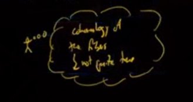

Cohomology of the fibers: but not quite!

This is not quite true, and the obstruction is called **the base change property**, which we’ll see later in the course. What’s true in general is that $R^i f_* \mathcal{F}$ is the sheafification of the presheaf $V\to H^i(f^{-1}(V), \mathcal{F})$, which is not quite the cohomology of the fibers since sheafification is somewhat brutal.

If $f$ is a finite morphism (e.g. a closed immersion) then $R^{>0} f_* = 0$.

Prove this. The claim is that $f_*$ is right-exact, which in this case shows it is exact. Check on stalks. Compute that the stalk of $f_* \mathcal{F}$ at $\mkern 1.5mu\overline{\mkern-1.5muy\mkern-1.5mu}\mkern 1.5mu\in Y$ is given by
$$\begin{align*}
f_* \mathcal{F}_{\mkern 1.5mu\overline{\mkern-1.5muy\mkern-1.5mu}\mkern 1.5mu} = \bigoplus_{\mkern 1.5mu\overline{\mkern-1.5mux\mkern-1.5mu}\mkern 1.5mu\in f^{-1}(\mkern 1.5mu\overline{\mkern-1.5muy\mkern-1.5mu}\mkern 1.5mu)}\mathcal{F}_{\mkern 1.5mu\overline{\mkern-1.5mux\mkern-1.5mu}\mkern 1.5mu}
\end{align*}
for \(f\) a finite morphism (not necessarily unramified).$$

$f_*$ preserves injectives.

Prove this! You can do this by showing the following fact from category theory: this is true for any functor with an exact left adjoint, which here is $f^*$ and is exact since filtered colimits and sheafification are both exact, or alternatively you can check on stalks, since the stalks of $f^{-1}$ are the stalks of the original functor.

Suppose $X \xrightarrow{f} Y$ and $Y \xrightarrow{g} Z$ are morphisms of schemes, then there is a spectral sequence
$$\begin{align*}
R^i g_* R^j f_* \mathcal{F} \Rightarrow R^{i+j}(g\circ f)_* \mathcal{F}
.\end{align*}
As a special case, for \(Z = \operatorname{Spec}k\) with \(k=\mkern 1.5mu\overline{\mkern-1.5muk\mkern-1.5mu}\mkern 1.5mu\), then \(g_*, f_*\) are taking global sections so we get
\begin{align*}
H^i(Y, R^j f_* \mathcal{F} ) \Rightarrow H^{i+j}(X, \mathcal{F})
.\end{align*}$$

There is a general statement (see Tohoku): given two functors between abelian functors where the first preserves injectives, you get such a spectral sequence. How to explicitly compute this: we can take an injective resolution $\mathcal{F}\to \mathcal{I}^{\,\cdot\,}$ and compute
$$\begin{align*}
R^i f_* \mathcal{F} \mathcal{H}^i(f_* \mathcal{I}^{\,\cdot\,})
.\end{align*}
\(f_* \mathcal{I}\) is a complex of injectives, and we want \(\mathcal{H}^{i+j}(g_* f_* \mathcal{I}^{\,\cdot\,}) = R^{i+j}(g\circ f)_* \mathcal{F}\), and the content here is that we don’t have to take an additional injective resolution of \(f_* \mathcal{I}\). Now take the spectral sequence of the filtered complex \(f_* \mathcal{I}^{\,\cdot\,}\) where the filtration is by the truncations \(\tau_{\leq p}f_* \mathcal{I}^{\,\cdot\,}\) where you replace the \(p\)th term with the kernel of the differential and zero beyond this point. An example of a differential is given by the following: there are SESs
\begin{align*}
0 \to
\tau_{\leq p} f_* \mathcal{I}^{\,\cdot\,}
\to
\tau_{\leq p+1} f_* \mathcal{I}^{\,\cdot\,}
\to
\mathcal{H}^{p+1}(f_* \mathcal{I}^{\,\cdot\,}) = R^{p+1} f_* \mathcal{F}
\to
0
,\end{align*}
and applying \(RG_*\) yields a map
\begin{align*}
R^{p+1} f_* \mathcal{F}
\xrightarrow{\delta}
R^{q+1} g_* \tau_{\leq p}f_* \mathcal{I}^{\,\cdot\,}
,\end{align*}
and after some splicing this \(\delta\) will be the differential on \(E_2\).$$

Next time: the Brauer group.

# 11 Lecture 11

## 11.1 Pushforwards (Continued)

Last time: we saw the Leray spectral sequence, but no examples yet, so that’s what we’ll do now. We had $X \xrightarrow{f} Y \xrightarrow{g} Z$ to which we associated the spectral sequence $R^i f_* R^jf_*({\,\cdot\,}) \Rightarrow R^{i+j}(g\circ f)_* ({\,\cdot\,})$. To deduce existence we used that pushforwards preserve injectives, and we looked at some $E_2$ differentials.

Let $X \xrightarrow{\pi} Z \mathrel{\vcenter{:}}=\operatorname{Spec}k$, where $k\neq \mkern 1.5mu\overline{\mkern-1.5muk\mkern-1.5mu}\mkern 1.5mu$ necessarily. The spectral sequence for the functors $\pi_*, \Gamma$ yields the Leray spectral sequence $H^i(k, R^j \pi_* \mathcal{F}) \Rightarrow H^{i+j}(X_\text{ét}, \mathcal{F})$. The LHS is the étale cohomology of $\operatorname{Spec}k$, i.e. Galois cohomology. The Galois module corresponding to $R^j \pi_* \mathcal{F}$ is $H^j(X_{k^{s}}, \mathcal{F})$ by taking the $\mkern 1.5mu\overline{\mkern-1.5muk\mkern-1.5mu}\mkern 1.5mu$ points of this functor So the Leray spectral sequence yields
$$\begin{align*}
H^i(k, H^j(X_{k^{s}, \text{ét}}, \mathcal{F} )) \Rightarrow H^{i+j}(X_\text{ét}, \mathcal{F})
.\end{align*}$$

Consider $k$ a finite field and $X_{/k}$ a smooth projective variety. Then the Galois cohomology is given by
$$\begin{align*}
H^i(k, V)
=
\begin{cases}
V^G & i = 0 \hspace{4em}\text{the invariants}\\
V_G & i = 1\hspace{4em}\text{the coinvariants} \\
0 & i>1
\end{cases}
\end{align*}
This follows from computing the cohomology of \(\widehat{{\mathbb{Z}}}\). Supposing we knew that the cohomological dimension of a smooth projective variety was \(2n\) over \(\mkern 1.5mu\overline{\mkern-1.5muk\mkern-1.5mu}\mkern 1.5mu\) (e.g. taking \(\mathcal{F} \mathrel{\vcenter{:}}=\mathbb{Z}/\ell\mathbb{Z}\) above), then the cohomological dimension of \(X\) would be \(2n+1\). This follows from \(E_2\) vanishing for \(i>1\) in this case.$$

A general fact about the Leray spectral sequence for smooth proper morphisms: let $X \xrightarrow{\pi} Y$ such a morphism, then there is a spectral sequence
$$\begin{align*}
H^i(Y, R^j \pi_* \underline{{\mathbb{Q}}}) \Rightarrow H^{i+j}(X, {\mathbb{Q}})
.\end{align*}
A fact due to Deligne is that this degenerates at \(E_2\), which is proved with \(\ell{\hbox{-}}\)adic cohomology (going through Weil II) using the theory of weights. Note that this is false for smooth proper morphisms between manifolds! Instead, for varieties, they behave more like products instead of “twisted” things.$$

### 11.1.1 Explicit Characterizations

We’ll now be explicit about what these pushforwards are, so we’ll give another description of them:

Let $X \xrightarrow{\pi} Y$, then $R^i \pi_* \mathcal{F}$ is the sheaf associated to the presheaf $U\to H^i(\pi^{-1}(U)_\text{ét}, \mathcal{F})$.

Choose an injective resolution $\mathcal{F}\to \mathcal{I}{\,\cdot\,}$, then $\mathcal{H}^i(\pi_* \mathcal{I}^{\,\cdot\,}) \mathrel{\vcenter{:}}= R^i \pi_* \mathcal{F}$. Let’s compute this pushforward in another way: we have

[figure not shown]

Here the induced map on presheaves is exact although the forgetful functor may not be. This is because a sequence of presheaves is exact iff it’s exact on every open, but $\pi_*$ just pulls back opens. This diagram commutes since what you get in the top-right corner is already a sheaf, and sheafification is the identity on sheaves. We can thus factor $\pi_*$ to obtain
$$\begin{align*}
R^i \pi_* \mathcal{F} = \mathcal{H}^i*\pi_* \mathcal{I}^{\,\cdot\,}
&= \mathcal{H}^i(a\circ \pi \circ f (\mathcal{I}^{\,\cdot\,})) \\
&= a\circ \pi_*\qty{\mathcal{H}^i(f(\mathcal{I}^{\,\cdot\,})) }
.\end{align*}
where we’ve used the fact that \(\pi_*, s\) are exact. Why isn’t the inner term zero, since \(\mathcal{I}^{\,\cdot\,}\) is an exact complex of sheaves? Epimorphisms are different in the categories of sheaves and presheaves, so it may not be exact when viewed as a complex of presheaves. These terms are explicitly the functors \(U\to H^i(U, \mathcal{F})\), since \({ \left.{{\mathcal{I}^{\,\cdot\,}}} \right|_{{U}} }\) is an injective resolution of \(\mathcal{F}\). We can now evaluate this on an open of \(Y\), so we get
\begin{align*}
a \qty{ (U \xrightarrow{\text{ét}} Y) \to H^i(\pi^{-1}(U), \mathcal{F}) }
,\end{align*}
which is sheafifying the functor we want.$$

### 11.1.2 Explicit Characterizations

Suppose $X$ is an integral scheme and $\eta\xhookrightarrow{\iota} X$ is its generic point. Suppose $\mathcal{F}\in {\operatorname{Sh}}(\eta_\text{ét})$. How to we understand $R^i \iota_* \mathcal{F}$? We can compute its stalks: suppose $\mkern 1.5mu\overline{\mkern-1.5mux\mkern-1.5mu}\mkern 1.5mu \to X$ is a geometric point, then
$$\begin{align*}
\qty{R^i \iota_* \mathcal{F}}_{\mkern 1.5mu\overline{\mkern-1.5mux\mkern-1.5mu}\mkern 1.5mu}
&=
\varinjlim_{(U, \mkern 1.5mu\overline{\mkern-1.5muu\mkern-1.5mu}\mkern 1.5mu)} \qty{R^i \iota_* \mathcal{F}}(U) \\
&=
H^i(U_\eta, { \left.{{\mathcal{F}}} \right|_{{U_\eta}} })
.\end{align*}
where we take limits over \(U\xrightarrow{\text{ét}} X\) and \(\mkern 1.5mu\overline{\mkern-1.5muu\mkern-1.5mu}\mkern 1.5mu\to U\) is a geometric point above \(\mkern 1.5mu\overline{\mkern-1.5mux\mkern-1.5mu}\mkern 1.5mu\).$$

Let ${\mathcal{O}}_{X, \mkern 1.5mu\overline{\mkern-1.5mux\mkern-1.5mu}\mkern 1.5mu}$[^25] be the stalk of ${\mathcal{O}}_X$ at $\mkern 1.5mu\overline{\mkern-1.5mux\mkern-1.5mu}\mkern 1.5mu$ and $K_{\mkern 1.5mu\overline{\mkern-1.5mux\mkern-1.5mu}\mkern 1.5mu}$[^26] be its fraction field. Then
$$\begin{align*}
\qty{R^i \iota_* \mathcal{F}}_{\mkern 1.5mu\overline{\mkern-1.5mux\mkern-1.5mu}\mkern 1.5mu}
=
H^i(K_{\mkern 1.5mu\overline{\mkern-1.5mux\mkern-1.5mu}\mkern 1.5mu}, { \left.{{\mathcal{F}}} \right|_{{K_{\mkern 1.5mu\overline{\mkern-1.5mux\mkern-1.5mu}\mkern 1.5mu}}} } )
,\end{align*}
where the RHS is either the Galois cohomology of \(k\) or the étale cohomology of \(\operatorname{Spec}k\).$$

Idea: these are the étale local rings, and this says you can compute the stalk of a cohomology sheaf in terms of these strictly Henselian local rings.

## 11.2 Étale Cohomology of Curves: Reducing to Galois Cohomology

Goal: we want to understand $H^{>1}(X, {\mathbb{G}}_m)$ where $X_{/k}$ is a curve over $k = k^{s}$ which is separably closed. We’ll reduce this to questions in Galois cohomology.

Let $X_{/k}$ (with $k$ not necessarily algebraically closed) be a regular (integral) variety and $\eta\hookrightarrow X$ is the generic point. Then there is a SES in ${\operatorname{Sh}}(X_\text{ét})$:
$$\begin{align*}
0 \to
{\mathbb{G}}_m
\xrightarrow{\operatorname{Res}}
\eta_* {\mathbb{G}}_m
\xrightarrow{\operatorname{Div}}
\bigoplus_{z\in X, \operatorname{codim}1} \iota_{z_*} \underline{{\mathbb{Z}}}
\to 0
,\end{align*}
where the middle term can be thought of as pushing forward \({\mathbb{G}}_m\) from the étale site of \(\eta\) or pulling back \({\mathbb{G}}_m\) to it, which is just \({\mathbb{G}}_m\) again, and pushing forward again, and the last term is the sheaf of divisors.$$

The first map is either the unit or the counit of the adjunction $\eta_* \rightleftharpoons\eta^*$, which is the restriction. The second map comes from noting that on an étale morphism $U\to X$, this is a bunch of rational functions and you can take its divisor. This gives a number for each codimension 1 point: the order of vanishing. All but finitely many numbers will be zero, so you get a section to the last sheaf.

**1**: ${\mathbb{G}}_m \to \eta_* {\mathbb{G}}_m$ is injective. This reduces to showing ${\mathbb{G}}_m(U) \to {\mathbb{G}}_m(U_\eta)$ is injective, where $U_\eta$ is the fiber over $\eta$, since this is ${\mathcal{O}}_U^{\times}\to \bigoplus_{\eta_i} {\mathcal{O}}_{\eta_i}$ which is a sum over generic points of $U$. This uses that $X$ is reduced.

**2**: Exactness in the middle. Given $f\in \eta_* {\mathbb{G}}_m(U)$ with $\operatorname{Div}(f) = 0$, we want to show $f$ comes from ${\mathbb{G}}_m(U)$. We need to show $f, f^{-1}$ are regular, and it’s enough to show that $f$ is regular. We’re using that if we have a finite type ring over a field $A$, then by a fact from commutative algebra,
$$\begin{align*}
A = \bigcap_{\mathfrak{p}\in \operatorname{Spec}^1(A)} A_{\mathfrak{p}}
\end{align*}
which is the intersection of localizations over all height 1 primes. Being in this intersection is equivalent to having non-negative divisors, where here we’ve used that regularity implies normality.$$

**3**: Surjectivity at the end. We need to show that every divisor is étale locally principle, and thus Zariski locally. A global section to the last sheaf is a Weil divisor, and we want to show each is principle. This is equivalent to being Cartier, which is true here by regularity.

There’s a LES:

[figure not shown]

The blue term is what we’d like to compute, and the other terms are the cohomology of pushforwards and thus appear in the Leray spectral sequence.

Let $X_{/k}$ be a curve where $k=k^{s}$. Then
$$\begin{align*}
H^{i>0}(X_\text{ét}, \bigoplus_{\operatorname{codim}z = 1} \iota_{z_*} {\mathbb{Z}}) = 0
.\end{align*}$$

It’s enough to show that $H^{>0}(X_\text{ét}, \iota_{z_*} \underline{{\mathbb{Z}}}) = 0$ using that cohomology commutes with direct sums. Using the Leray spectral sequence, we get
$$\begin{align*}
H^i(X_\text{ét}, R^j_{\iota_{z_*}} \underline{{\mathbb{Z}}})\Rightarrow H^{i+j}(z_\text{ét}, \underline{{\mathbb{Z}}})
\end{align*}
What are the coefficients on the LHS? We proved that pushforwards on closed immersions are exact, by checking on stalks, so we have$$

$$\begin{align*}
R^j _{\iota_{z_*}} \underline{{\mathbb{Z}}}
=
\begin{cases}
\iota_{z_*} \underline{{\mathbb{Z}}}& j = 0 \\
0 & j > 0
\end{cases}
.\end{align*}$$

We can also compute
$$\begin{align*}
H^s(z_\text{ét}, \underline{{\mathbb{Z}}})
=
\begin{cases}
{\mathbb{Z}}& s = 0 \\
0 & s>0
\end{cases}
.\end{align*}
since the zero term is global sections and \(k\) is separably (algebraically) closed, and the Galois cohomology vanishes in \(i>0\). So we get a degenerate spectral sequence with one column, yielding
\begin{align*}
H^i (X_\text{ét}, \iota_{z_*} \underline{{\mathbb{Z}}})
=
H^i(z_{\text{ét}}, {\mathbb{Z}})
=
\begin{cases}
{\mathbb{Z}}& i = 0 \\
0 & i> 0
\end{cases}
.\end{align*}$$

If $X_{/k}$ is a smooth curve over $k=k^{s}$ then we have an isomorphism
$$\begin{align*}
H^{>1}(X_\text{ét}, {\mathbb{G}}_m) \xrightarrow{\sim}H^{>i}(X_\text{ét}, \eta_* {\mathbb{G}}_m)
.\end{align*}$$

New goal: compute the RHS, which is not quite Galois cohomology but is pushed forward from a field. Using the Leray spectral sequence, we get \begin{align*} H^i(X_\text{ét}, R^j \eta_* {\mathbb{G}}_m) \Rightarrow H^{i+j}(\eta, {\mathbb{G}}_m) ,\end{align*} where the RHS is Galois cohomology. We’re interested in the $j=0$ region of the spectral sequence. Let’s try to understand the stalks at geometric points: \begin{align*} \qty{R^j \eta_* {\mathbb{G}}_m}_{\mkern 1.5mu\overline{\mkern-1.5mux\mkern-1.5mu}\mkern 1.5mu} = H^j(K_{\mkern 1.5mu\overline{\mkern-1.5mux\mkern-1.5mu}\mkern 1.5mu}, {\mathbb{G}}_m) ,\end{align*} where the field appearing is the *strict Henselization* from the earlier discussion. We’ll be able to compute this if we have the following theorem:

Let $K$ be the function field of a curve or an algebraically closed field, or $K = K_{\mkern 1.5mu\overline{\mkern-1.5mux\mkern-1.5mu}\mkern 1.5mu}$ is the strict Henselian field of a geometric point of a curve over a separably (algebraically) closed field. Then
$$\begin{align*}
H^{>0}(K, {\mathbb{G}}_m) = 0
.\end{align*}$$

This will suffice since $R^{>0} \eta_*{\mathbb{G}}_m = 0$, yielding a spectral sequence where $E_2 = E_ \infty$:
$$\begin{align*}
H^i(X_\text{ét}, \eta_* {\mathbb{G}}_m)
=
H^i(\eta,{\mathbb{G}}_m)
=
0 && \text{if }i>0
.\end{align*}$$

**Upshot**: this reduces the computation of the étale cohomology of a curve to Galois cohomology. Proving this theorem is hard, and will lead us to Brauer groups.[^27]

## 11.3 Brauer Groups

Let $X$ be a scheme, then the **cohomological Brauer group** is defined as
$$\begin{align*}
\operatorname{Br}(X) \mathrel{\vcenter{:}}= H^2(X_\text{ét}, {\mathbb{G}}_m)_{{\operatorname{tors}}}
.\end{align*}$$

In good situations, this group has a good geometric interpretation, so let’s true to understand it this way in terms of $\operatorname{PGL}_n{\hbox{-}}$torsors.

There is a natural map
$$\begin{align*}
\bigcup_n \left\{{ \text{étale-locally split $\operatorname{PGL}_n{\hbox{-}}$torsors} }\right\}
\to
H^2(X_\text{ét}, {\mathbb{G}}_m)
.\end{align*}$$

Idea: there is a SES \begin{align*} 1 \to {\mathbb{G}}_m \to \operatorname{GL}_n \to \operatorname{PGL}_n \to 1 && \in {\operatorname{Sh}}^{{\operatorname{Grp}}}(X_\text{ét}) .\end{align*} It’s not obviously exact on the right, since it’s not quite true that a map into $\operatorname{PGL}_n$ is an invertible matrix modulo scaling: this is true locally, but it’s the *sheafification* of this, so why is there a surjection? The key input is that $\operatorname{GL}_n\to \operatorname{PGL}_n$ is smooth, and thus has sections étale-locally. This map is a ${\mathbb{G}}_m{\hbox{-}}$torsor, which we know are Zariski-locally trivially, so this sequence is exact in the Zariski topology and thus also in the étale topology.

Suppose $T$ is an étale-locally trivial $\operatorname{PGL}_n{\hbox{-}}$torsor, then the LES essentially has the following map: \begin{align*} \cdots \to H^2(X_\text{ét}, \operatorname{PGL}_n) \xrightarrow{\delta} H^2(X_\text{ét}, {\mathbb{G}}_m) \to \cdots .\end{align*} This doesn’t make sense *a priori* since this is not a sequence of abelian sheaves. Let’s true to associate to $T$ some $[T]\in H^2(X_\text{ét}, {\mathbb{G}}_m)$. We can first write down $[T] \in {\check{H}}^1(X_\text{ét}, \operatorname{PGL}_n)$: we get a $\operatorname{PGL}_n$ cocycle out a torsor by choosing a trivializing map $U\to X$ so that ${ \left.{{T}} \right|_{{U}} } = { \left.{{\operatorname{PGL}_n}} \right|_{{U}} }$. This yields a cocycle in $\operatorname{PGL}_n(U\times_X U)$.

> To be continued.

# 12 Lecture 12

## 12.1 Brauer Groups

Goal: for $C$ a curve over $k=\mkern 1.5mu\overline{\mkern-1.5muk\mkern-1.5mu}\mkern 1.5mu$, we’ve computed \begin{align*} H^i(C, {\mathbb{G}}_m) = \begin{cases} {\mathcal{O}}_C^{\times}(C) & i=0\\ {\operatorname{Pic}}(C) & i=1 \\ 0 & i > 1 \end{cases} .\end{align*} Currently $i>1$ is a mystery, so today we’ll look at $i=2$. Recall that we’ve reduced this to the Galois cohomology of the function field $H^i(k(C), {\mathbb{G}}_m)$ and of the strict Henselization[^28] $H^i(K_{\mkern 1.5mu\overline{\mkern-1.5mux\mkern-1.5mu}\mkern 1.5mu}, {\mathbb{G}}_m)$.

Today we’ll try to understand the Galois cohomology of a field with coefficient in $\mkern 1.5mu\overline{\mkern-1.5muk\mkern-1.5mu}\mkern 1.5mu^{\times}$, or ${\mathbb{G}}_m$ thought of as a sheaf on the étale site. We’ll discuss $i=2$, and a general principle in group cohomology is that if one understands $i=1, 2$ then one can often understand all degrees.

In general, $H^1$ has a geometric interpretation: torsors. $H^2$ is much harder: they classify more general objects called **gerbes**. A miracle is that $H^2({\mathbb{G}}_m)$ has real meaning, and is very closely related to real physical objects (certain torsors). Recall that we defined the *cohomological Brauer group of $X$* () as
$$\begin{align*}
\operatorname{Br}^{\operatorname{coh}}\mathrel{\vcenter{:}}=\operatorname{Br}'(X) \mathrel{\vcenter{:}}= H^i(X_\text{ét}, {\mathbb{G}}_m)_{{\operatorname{tors}}}
.\end{align*}$$

We also started defining the Brauer group by considering \begin{align*} \bigcup_n \left\{{\text{étale locally trivial } \operatorname{PGL}_n{\hbox{-}}\text{torsors}}\right\} \xrightarrow{\delta} H^2(X_\text{ét}, {\mathbb{G}}_m) ,\end{align*} and defining $\operatorname{Br}(X) \mathrel{\vcenter{:}}=\operatorname{im}f$ as a set, which is a reasonably concrete geometric object. This map came from a LES in cohomology, coming from a SES of sheaves, not all of which were abelian. The definition of $\delta$ was the boundary map of \begin{align*}\label{eq:12_union_1} \bigcup_n H^1(X_\text{ét}, \operatorname{PGL}_n) \xrightarrow{\delta} H^2(X_\text{ét}, {\mathbb{G}}_m) \end{align*} arising from the SES of sheaves of groups on $X_\text{ét}$, \begin{align*} 1 \to {\mathbb{G}}_m \xrightarrow{} \operatorname{GL}_m \xrightarrow{} \operatorname{PGL}_n \to 1 .\end{align*} We argued last time that this was exact in the Zariski topology since the RHS map was a ${\mathbb{G}}_m{\hbox{-}}$ torsor and thus Zariski locally trivial. What does $\delta$ mean?[^29]

Making the LES here is a little subtle. You get a long exact sequence of *sets* here which terminates at the $H^2$ we’re interested in, although one usually doesn’t get a map of the form $H^1(C) \to H^2(B)$ for a SES $A \xrightarrow{}B \xrightarrow{}C$, you need that $A$ is abelian (or in the center).

We’ll now try to make $\delta$ explicit in terms of Čech cohomology, which is the only way we have to make sense of the LHS set in . We defined it to be the set of étale locally trivial $\operatorname{PGL}_n{\hbox{-}}$ torsors, which has a description in terms of ${\check{H}}^1$ : the boundary map doesn’t usually make sense for a nonabelian group, but it does in very low degrees such as $i=1$. So we need to implement the snake lemma. Start with $[T]\in H^i(X_\text{ét}, \operatorname{PGL}_n)$ where $T$ is a $\operatorname{PGL}_n{\hbox{-}}$ torsor split by $U\xrightarrow{}X$. On $U\times_X U$, descent data is given by a section $\Gamma(U\times_X U, \operatorname{PGL}_n)$ as a sheaf. This is because descent data is an isomorphism on this double intersection and an automorphism of $\operatorname{PGL}_n$ is the same as a section to $\operatorname{PGL}_n$. This descent data satisfies the cocycle condition. How do we apply the boundary map to an element in the Čech complex? After refining $U$ we can lift this descent data to a section $s\in \Gamma\qty{U\times_{X}U,GL_{n}}$. Note that $H^{2}\qty{{\mathbb{G}}_{m}}$ is represented by a section to ${\mathbb{G}}_{m}$ of $U\times_{X}U\times_{X}U$. We started with something satisfying the cocycle condition but lifted in an arbitrary way, so it may not still satisfy the cocycle condition. We can write
$$\begin{align*}
\pi_{23}^{*}\pi_{12}^{*}s \qty{\pi_{13}s}^{-1}
\in \Gamma\qty{U\times_{X}U\times_{X}U, {\mathbb{G}}_{m}}
.\end{align*}$$

A priori it’s just a section to $\operatorname{GL}_{n}$ but we know that this goes to 1 in $\operatorname{PGL}_{n}$, meaning it must comes from ${\mathbb{G}}_{m}$. The LHS is a 2-cocycle representing an element of $H^{2}\qty{X_{\text{ét}}, {\mathbb{G}}_{m}}$.

Check that $d$ of this element is zero.

$\delta\qty{[T]}$ is the obstruction to lifting a $\operatorname{PGL}_{n}{\hbox{-}}$torsor $T$ to a $\operatorname{GL}_{n}{\hbox{-}}$torsor. If this class vanishes, a lift exists.

This is what you might expect: the image of something coming from a boundary map is the obstruction to coming from the previous map. This class is called the **Brauer class of $T$**.

We’ve just mapped from a set to a group, so we don’t know that the image is a group yet, and we don’t yet know that the image is in $\operatorname{Br}^{\operatorname{coh}}$ since we don’t know if the image is torsion.

### 12.1.1 Geometric Interpretations of $\operatorname{PGL}_{n}{\hbox{-}}$Torsors Brauer Classes

There is a general principle: suppose $T\in{\operatorname{Sh}}^{{\operatorname{Set}}}\qty{X_{\text{ét}}}$ and $G = \underline{{\operatorname{Aut}}}\qty{T}$ as a sheaf, whose sections are given on an open $U$ by pulling back $T$ to $U$ and compute its automorphisms, where for example $T$ is a scheme. There is a natural bijection

$$\begin{align*}
\left\{{\substack{\text{ Locally split } \\ G{\hbox{-}}\text{torsors}}}\right\}
&\rightleftharpoons
\left\{{\substack{\text{ forms of } T}}\right\}
.\end{align*}
An example of this has come up before: namely that \(\operatorname{GL}_{n}{\hbox{-}}\)torsors corresponded to vector bundles. This is recovered by taking \(T\) to be the trivial vector bundle and \(G=\operatorname{GL}_{n}\) Here a form is defined to be a sheaf on \(X_{\text{ét}}\) locally isomorphic to \(T\). The map here is given by sending a form \(F\) to \(\underline{\mathrm{Isom}}\qty{F, T}\). This is locally split since \(F\) is locally trivial, i.e. locally isomorphic to \(T\), and so base-changing to some cover where \(F\) will make this torsor split. The reverse map is sending \(\tau \to \qty{\tau\times T}/G\), taking the sheaf quotient, which gets rid of \(\tau\) and making the fibers isomorphic to \(T\) instead.$$

$\operatorname{GL}_{n}{\hbox{-}}$torsors correspond to vector bundles. Note that this isn’t an equivalence of categories: there are maps of vector bundles which don’t come from maps of torsors, e.g. any map that is not an isomorphism. Here the left/right arrows mean that there is a bijection between *sets*, up to isomorphism on each side.

Let $G=\operatorname{PGL}_{n}$, then what are objects with automorphism group ${\operatorname{Aut}}\qty{G} = \operatorname{PGL}_{n}$? An example that works here is ${\operatorname{Aut}}_{x}\qty{{\mathbb{P}}_{x}} = \operatorname{PGL}_{n}$.

You may have seen this stated over an algebraically closed based field, but (nontrivially) this holds over a general base. Prove this.

*(Hint: you may need to use the theorem on formal functions or formal GAGA.)*

There is a natural bijection \begin{align*} \left\{{\substack{\operatorname{PGL}_{n}{\hbox{-}}\text{torsors}}}\right\} &\rightleftharpoons \left\{{\substack{\text{Forms of } {\mathbb{P}}^{n-1}}}\right\} \end{align*} These are referred to as **Severi-Brauer $X{\hbox{-}}$Schemes**[^30] .

How can we combine these to send forms of ${\mathbb{P}}^{n-1}$ directly to an Azumaya algebra?

Key takeaway: the Brauer group (which we’ll soon prove is a group) has concrete representative. These are the forms of ${\mathbb{P}}^{n-1}$, which you can think of as étale locally trivial ${\mathbb{P}}^{n-1}$ bundles, or forms of a matrix algebra, i.e. coherent sheaves of algebras which étale locally endomorphisms of the trivial bundle.

## 12.2 Twisted Sheaves

People usually think about Brauer groups as one of these two objects. We’ll discuss a third way. When we defined the boundary map, we took descent data from $\operatorname{PGL}_n$, i.e. elements of this group on double intersections, and we lifted those to $\operatorname{GL}_{n}$.

Let $U \to X$ be an étale cover and suppose $\alpha \in \Gamma(U \times_{X} U \times_{X} U, {\mathbb{G}}_{m})$ represents $[\alpha] \in H^{s}i(X_{\text{ét}}, {\mathbb{G}}_{m})$. Then an **$\alpha{\hbox{-}}$twisted sheaf** is a quasicoherent sheaf on $U$, an isomorphism $\varphi:\pi_{1}^{*} \mathcal{F} \xrightarrow{\sim}\pi_{2}^{*} \mathcal{F}$ (which looks like descent data) which satisfies the cocycle condition up to $\alpha$, i.e.
$$\begin{align*}
\pi_{23}^{*} \phi \circ \pi_{12}^{*}\phi = \alpha \pi_{13}^{*}\phi
.\end{align*}$$

Note that if $\alpha$ were the constant function 1, this would be the descent data for a quasicoherent sheaf, so we’re twisting what it means to be a sheaf. This is exactly what we did when defining a $\operatorname{PGL}_{n}{\hbox{-}}$torsor, where we lifted to get isomorphisms between the $\operatorname{GL}_{n}$ sheaves on the double overlaps. These failed to satisfy the cocycle condition, and the Brauer class measured this failure. So in defining $\delta$, our intermediate step was a twisted sheaf.

So we’ll define the category ${\mathrm{QCoh}}(X, \alpha)$ whose objects are $\alpha{\hbox{-}}$twisted sheaves and whose morphisms are morphisms of sheaves on $U$ commuting with $\varphi$.

${\mathrm{QCoh}}(X, 1)$ is canonically isomorphic to ${\mathrm{QCoh}}(X)$, which is the very famous theorem of *étale descent*.

### 12.2.1 Categorical Properties

Let $\alpha, \alpha'$ be two cocycles for ${\mathbb{G}}_{m}$. Then

1. $[\alpha]\in\operatorname{Br}(X)$ (so its in the image the boundary map from $\operatorname{PGL}_{n}$) iff there exist a twisted vector bundle.[^31]
2. ${\mathrm{QCoh}}(X,\alpha)$ is an abelian category (easy) and has enough injectives (hard) is $X$ is “nice.”
3. There is a functor \begin{align*} \otimes: {\mathrm{QCoh}}(X, \alpha) \times{\mathrm{QCoh}}(X, \alpha') \xrightarrow{} {\mathrm{QCoh}}(X, \alpha \alpha') ,\end{align*} where is $\alpha,\alpha'$ are defined on different covers than one passes to a common refinement, and a functor[^32]
   $$\begin{align*}
   \hom: {\mathrm{QCoh}}(X, \alpha) \times{\mathrm{QCoh}}(X, \alpha') \xrightarrow{}
   {\mathrm{QCoh}}(X, \alpha' \alpha^{-1})
   .\end{align*}$$
4. There are functors

$$\begin{align*}
\operatorname{Sym}^{n}, \Lambda^{n} \xrightarrow{} {\mathrm{QCoh}}(X, \alpha) \xrightarrow{} {\mathrm{QCoh}}(X, n \alpha)
.\end{align*}$$

5. ${\mathrm{QCoh}}(X, q) \xrightarrow{\sim}{\mathrm{QCoh}}(X)$.

For (1), if $\alpha\in \operatorname{Br}(X)$, then there is $\operatorname{PGL}_{n}{\hbox{-}}$torsor whose boundary is $\alpha$, and our construction of $\delta$ yielded an $\alpha{\hbox{-}}$twisted vector bundle. Given such a bundle, one can obtain a Brauer class by constructing a twisted form a ${\mathbb{P}}^{n}$: take the projectivization. Then the quasi descent data becomes actual descent data since the failure was precisely in scalars, which you’re now modding out by.

For (3), just work out what happens to $\alpha, \alpha'$ when tensoring or homming. Similarly, all of the rest except for **(2)** follow from definitions.

Try to prove (3) and (4).

### 12.2.2 The Brauer Group is a Group

$\operatorname{Br}(X)$ is a group.

Let $\mathcal{E}, \mathcal{E}'$ be $\alpha,\alpha'{\hbox{-}}$twisted vector bundles respectively, we want to show that there exists an $\alpha\alpha'{\hbox{-}}$twisted vector bundle. We can take $\mathcal{E}\otimes\mathcal{E}'$, and then just note that having a twisted vector bundle is the same as having a Brauer class. For inverses, suppose $\alpha$ is a Brauer class and $\mathcal{E}$ is a twisted vector bundle. To get an $\alpha^{-1}{\hbox{-}}$twisted vector bundle, one can just take the dual $\mathcal{E}^\vee$.

## 12.3 Results On Twisted Bundles

Suppose that $\alpha$ is a 2-cocycle for ${\mathbb{G}}_{m}$, then $[\alpha]$ is trivial iff there exists an $\alpha{\hbox{-}}$twisted line bundle.

If $[\alpha] = [\alpha']$, then ${\mathrm{QCoh}}(X,\alpha) \simeq {\mathrm{QCoh}}(X, \alpha')$.

Note that this is not a canonical equivalence.

Prove this lemma.

If $\alpha$ is trivial, then $[\alpha] = [1]$ in which case ${\mathrm{QCoh}}(X,\alpha) \simeq {\mathrm{QCoh}}(X)$ are equivalent categories and ${\mathcal{O}}_{X}$ is an honest line bundle.

Suppose you have an $\alpha{\hbox{-}}$twisted line bundle. Then writing down a line bundle is done by taking a cover, taking the trivial bundle on each open, and then the double intersections have gluing data in the form of $s\in \Gamma({\mathbb{G}}_{m})$. To prove $\alpha$ is a trivial Brauer class, note that the descent data (gluing data) is the same as a section $\beta\in \Gamma(U \times_{X} U, {\mathbb{G}}_{m})$. Then the Čech differential $\check{\delta}$ satisfies $\check{\delta}(\beta)=\alpha$, and thus by definition $\alpha = 0 \in H^{2}({\mathbb{G}}_{m})$.

Suppose $\mathcal{E}$ is an $\alpha{\hbox{-}}$twisted vector bundle of rank $n$. Then $[\alpha]\in H^{2}(X_{\text{ét}}, {\mathbb{G}}_m)$ is $n{\hbox{-}}$torsion.

We’ve just proved this for $n=1$, so for the general case, note that we can consider $\Lambda^{n}\mathcal{E}$ is a $\alpha^{n}{\hbox{-}}$twisted line bundle. Then by the previous proposition, $[\alpha^{n}] - [\alpha]^{n}$ is trivial.

$$\begin{align*}
\operatorname{Br}(X) \subseteq \operatorname{Br}'(X) = H^{2}(X_{\text{ét}}, {\mathbb{G}}_{m})_{{\operatorname{tors}}}
.\end{align*}$$

### 12.3.1 Examples of Brauer Classes

. $X\mathrel{\vcenter{:}}=\left\{{ x^{2}+y^{2}+z^{2} = 0}\right\}$ over ${\mathbb{R}}$ is a smooth conic with no rational points. We now via stereographic projection that a smooth projective conic with a rational point would be isomorphic to ${\mathbb{P}}^{1}$, so this becomes isomorphic to ${\mathbb{P}}^{1}$ after base-changing to ${\mathbb{C}}$ where it does have a rational point. So $X_{/{\mathbb{C}}} \cong {\mathbb{P}}^{1}$, which implies that $X$ is a twisted form of ${\mathbb{P}}^{1}_{{\mathbb{R}}}$. In fact, $\delta\qty{[X]}$ generates $\operatorname{Br}({\mathbb{R}}) = {\mathbb{Z}}/2{\mathbb{Z}}$.

2. Hamilton’s Quaternions are a division algebra and hence an Azumaya algebra representing the same element.

Given an $\alpha{\hbox{-}}$twisted sheaf $\mathcal{E}$, taking the projectivization yields a Severi-Brauer. Since $\mathcal{E}$ was a vector bundle with descent data twisted by a scalar and projectivizing kills scalars, this yields honest descent data. But descent data is not effective for schemes. So to say that this is actually a variety instead of a sheaf representing this descent, an extra argument is needed: projective space is anti-canonically polarized. Descent data for a polarized variety – a variety plus an ample line bundle – then descent is effective, and projective space has a canonical polarization given by the dual of the canonical sheaf.

Taking $\operatorname{End}(\mathcal{E})$ yields an Azumaya algebra since taking $\operatorname{End}$ here kills the twisting cocycle and yields an honest sheaf of algebras. It’s locally isomorphic to a matrix algebra since passing to any cover where $\mathcal{E}$ is trivialized yields a matrix algebra. Moreover, there is a way to go from Azumaya algebras to Severi-Brauers, by taking moduli of certain ideals, so we have a diagram

[figure not shown]

An example from class field theory: $\operatorname{Br}({\mathbb{Q}}_{p}) = {\mathbb{Q}}/{\mathbb{Z}}$.

Over a field, any 2-torsion Brauer class is represented by a quaternion algebra: using the usual formula where e.g. $i^{2} = -1$, you change $-1$ to some other numbers. In particular, the coset $[{1\over 2}] \in {\mathbb{Q}}/{\mathbb{Z}}$ is represented by an algebra resembling the usual quaternions.

There is a map

$$\begin{align*}
0 \xrightarrow{} \operatorname{Br}({\mathbb{Q}}) \xrightarrow{} \bigoplus_{r\in P_{{\mathbb{Q}}}} \operatorname{Br}({\mathbb{Q}}_{r})
\xrightarrow{\epsilon} {\mathbb{Q}}/{\mathbb{Z}}\xrightarrow{} 0
,\end{align*}
where \(P\) is the set of places of \({\mathbb{Q}}\) including \(\infty\) (i.e. \({\mathbb{R}}\)) and the summands are the completions of \({\mathbb{Q}}\) at each place.$$

How to interpret multiplication: let $\mathcal{A}_{1}, \mathcal{A}_{2}$ be Azumaya algebras representing $\alpha_{1}, \alpha_{2}$, then $\mathcal{A}_{1} \otimes\mathcal{A}_{2}$ is an Azumaya algebra representing $\alpha_{1} \cdot \alpha_{2}$. This follows because being an Azumaya algebra is a local property, so one can just pass to a cover where this reduces to a fact that matrix algebras are closed under tensor products.

It’s not easy to write down equations for Severi-Brauers. We can do this for curves (conics), but surfaces are difficult and we don’t know how to do much for threefolds.

(The Period-Index question) Given $\alpha\in\operatorname{Br}(X)$, what is the minimum rank or the $\gcd$ of the ranks of an $\alpha{\hbox{-}}$twisted vector bundle? We can do this for 2-torsion over a field, but this is generally a hard question. In general, if you have an $\alpha{\hbox{-}}$twisted bundle of rank $n$ then it’s $n{\hbox{-}}$torsion, but the converse is known by examples not to be true. Asking for explicit (and small) representatives of these objects is generally a hard question.

Next time: use this theory to understand $H^i(k, {\mathbb{G}}_m)$ for $k$ a field. We’ll try to prove the following:

1. If $K(C)$ is the function field of a curve over $k = \mkern 1.5mu\overline{\mkern-1.5muk\mkern-1.5mu}\mkern 1.5mu$, then $H^2(K(C), {\mathbb{G}}_m) = 0$ and thus $\operatorname{Br}(K) = 0$.
2. If $K_{\mkern 1.5mu\overline{\mkern-1.5muk\mkern-1.5mu}\mkern 1.5mu}$ is strictly Henselian, then $H^2(K_{\mkern 1.5mu\overline{\mkern-1.5mux\mkern-1.5mu}\mkern 1.5mu}, {\mathbb{G}}_m) = 0$.

This will be the key ingredient in computing the étale cohomology of curves.

# 13 Lecture 13 (todo)

# 14 Lecture 14 (todo)

# 15 Lecture 15 (todo)

# 16 Lecture 16 (todo)

# 17 Lecture 17 (todo)

# 18 Lecture 18 (todo)

# 19 Lecture 19 (todo)

# 20 Lecture 20 (todo)

# 21 Lecture 21 (todo)

# 22 Lecture 22 (todo)

# 23 Lecture 23 (todo)

# 24 Lecture 24 (todo)

# 25 Lecture 25 (todo)

# 26 Lecture 26 (todo)

# 27 Lecture 27 (todo)

# 28 Lecture 28 (todo)

# 29 Lecture 29 (todo)

# 30 Lecture 30 (todo)

[^1]: A **geometric point** is a map from $\operatorname{Spec}X$ to an algebraically closed field.
[^2]: Note that we’ll generalize Betti numbers so this makes sense in general.
[^3]: You should check to make sure you know why this is true!
[^4]: Exercise: justify why the reduction is valid.
[^5]: Here $H^i_c$ is compactly supported cohomology, we’ll define this later in the course.
[^6]: Intersection with a hyperplane in projective space.
[^7]: Here we use the convention that everything is prime to zero. Also note that this map is in fact finite étale.
[^8]: What do you have to check? Locally finite presentation, flat, and unramified are all preserved. The one that may be tricky is remaining unramified, a hint is to use the cotangent exact sequence for $\Omega^1_{X/Y}$.
[^9]: Recall that a presheaf on $X$ is a contravariant functor out of the category of open sets of $X$.
[^10]: The notion of a presheaf on $X$ doesn’t know much about the actual topology of $X$. If two spaces have the coarsest topology, so the only opens are $X, \emptyset$, then the categories of open sets are equivalent, and every presheaf on them will be the same.
[^11]: How to think of this: elements in this collection cover $X$.
[^12]: When $\mathcal{C}$ was the category of open sets of a space $X$, the existence of this morphism $Y\to X$ says $Y \subseteq X$ is an open subset, and thus intersecting $Y$ with any open cover of $X$ yields an open cover of $Y$.
[^13]: For spaces, this says if you have a cover of an open set by subsets and a cover of each of those subsets, the entire set has been covered.
[^14]: The letters don’t precisely match up here because this comes from a French acronym.
[^15]: Note that a sheaf on the big étale site necessarily restricts to a sheaf on the small étale site, since covers in the small site are also covers in the big site.
[^16]: Note that this functor goes in the opposite direction of the original map.
[^17]: If $U$ was an open cover, this would correspond to intersections of elements in the cover.
[^18]: Note that having any cofinal diagrams in a limit means that the limit will only see those.
[^19]: I.e. a given section of $\mathcal{G}$ may not be in the image of $\mathcal{F}$, but will be after refining the cover.
[^20]: $G$ is a topological group in the inverse limit topology, so a discrete $G{\hbox{-}}$module is a module with the discrete topology where the $G{\hbox{-}}$action is continuous. In particular, the action on any element factors through a finite quotient of $G$.
[^21]: Here a curve will be a smooth separated scheme of finite type of dimension 1 over an algebraically closed field. We won’t assume properness, and we’ll generalize to singular curves.
[^22]: A sheaf of groups is a group object in the category ${\operatorname{Sh}}^{\operatorname{Set}}$.
[^23]: This is called “90” since Hilbert numbered his theorems in at least one of his books.
[^24]: See Hartshorne Ch. 4, or anything that discusses cohomology of curves.
[^25]: The **strictly Henselian ring** of $X$ at $\mkern 1.5mu\overline{\mkern-1.5mux\mkern-1.5mu}\mkern 1.5mu$.
[^26]: The **strictly Henselian field** of $X$ at $\mkern 1.5mu\overline{\mkern-1.5mux\mkern-1.5mu}\mkern 1.5mu$.
[^27]: Another one of Daniel’s favorite topics in the course!
[^28]: The stalk of the structure sheaf, ${\mathcal{O}}_{C,x}$.
[^29]: Best reference: Giraud, “Cohomologie non Abelienne.”
[^30]: If $x = \operatorname{Spec}k$ is a point, then these are referred to as **Severi-Brauer Varieties**.
[^31]: Note that we’ve proved this already since $\operatorname{Br}= \operatorname{im}\delta$, but part of our construction of $\delta$ involved constructing an $\alpha{\hbox{-}}$twisted sheaf out of a $\operatorname{PGL}_{n}{\hbox{-}}$torsor.
[^32]: This and the tensor functor come from homming (resp. tensoring) the sheaves together and using the pseudo descent data.